# Aircraft Wildlife Strikes_2025-08-23_08-08-45_clean_2025-08-23_08-08-45

[figure not shown]

## **Introduction**

The project focuses on analyzing aircraft–bird strike incidents and classifying their outcome severity. The data come from the open FAA Wildlife Strikes dataset covering 1990–2024 and describing over 300,000 incidents.

The FAA Wildlife Strikes database provides detailed information on each bird strike — from phase of flight and aircraft parameters to environmental conditions and the final result (scale of a damage).

The aim of this project is to build and compare three classifiers (Logistic Regression, Random Forest, XGBoost) to predict aircraft damage (binary classification: damage vs. no damage), and then assess how balancing the highly imbalanced target class (≈10% damage) affects accuracy, precision, recall, and F1 metrics.

1. Data import and preliminary cleaning
2. Exploratory Data Analysis (EDA)
3. Missing Data Imputation
4. Data preparation
5. Model training
6. Evaluation and conclusions

## **1 - Data Importing & Preliminary Cleaning**

### 1.1 - Setting the Environment

```python
!pip install -q airportsdata
!pip install -q timezonefinder
!pip install -q pytz
!pip install -q astral
```

```
   ━━━━━━━━━━━━━━━━━━━━━━━━━━━━━━━━━━━━━━━━ 912.7/912.7 kB 32.4 MB/s eta 0:00:00
   ━━━━━━━━━━━━━━━━━━━━━━━━━━━━━━━━━━━━━━━━ 28.0/28.0 MB 44.0 MB/s eta 0:00:00
   ━━━━━━━━━━━━━━━━━━━━━━━━━━━━━━━━━━━━━━━━ 1.0/1.0 MB 37.1 MB/s eta 0:00:00
```

```python
# ——— Data Handling ———
import pandas as pd
import numpy as np

# ——— File Download & Utilities ———
import gdown
from IPython.display import display
from tqdm.auto import tqdm
import os
import glob

# ——— Visualization ———
import matplotlib.pyplot as plt
import seaborn as sns
import plotly.express as px
import plotly.graph_objects as go
from plotly.subplots import make_subplots

# ——— Geolocation & Time Calculation ———
from airportsdata import load
from timezonefinder import TimezoneFinder
from datetime import datetime
from astral import LocationInfo
from astral.sun import sun
import pytz

# ——— Machine Learning ———
from sklearn.model_selection import train_test_split, StratifiedKFold
from sklearn.preprocessing import RobustScaler
from sklearn.metrics import (
    confusion_matrix,
    accuracy_score,
    precision_score,
    recall_score,
    f1_score
)
from sklearn.linear_model import LogisticRegression
from sklearn.ensemble import RandomForestClassifier
from sklearn.metrics import confusion_matrix
from xgboost import XGBClassifier


pd.set_option('display.max_columns', None)
pd.set_option('display.max_colwidth', None)

import warnings
warnings.filterwarnings("ignore", category=RuntimeWarning)
warnings.filterwarnings("ignore", category=FutureWarning)
```

### 1.2a - Data Importing (gdown)

```python
file_id = "1Lt8PXOu575pnmlSfpGXn1GjWa3K-2KFW"
url = f"https://drive.google.com/uc?id={file_id}"
gdown.download(url, "faa_aws.csv", quiet=True)

df = pd.read_csv("faa_aws.csv", low_memory=False)
df = df[df["INCIDENT_YEAR"] <= 2024]

display(df.drop(columns=['REMARKS']).head())
```

|  | INDEX_NR | INCIDENT_DATE | INCIDENT_MONTH | INCIDENT_YEAR | TIME | TIME_OF_DAY | AIRPORT_ID | AIRPORT | AIRPORT_LATITUDE | AIRPORT_LONGITUDE | RUNWAY | STATE | FAAREGION | LOCATION | OPID | OPERATOR | REG | FLT | AIRCRAFT | AMA | AMO | EMA | EMO | AC_CLASS | AC_MASS | TYPE_ENG | NUM_ENGS | ENG_1_POS | ENG_2_POS | … |
| --- | --- | --- | --- | --- | --- | --- | --- | --- | --- | --- | --- | --- | --- | --- | --- | --- | --- | --- | --- | --- | --- | --- | --- | --- | --- | --- | --- | --- | --- | --- |
| 0 | 608242 | 1996-06-22 | 6 | 1996 | NaN | NaN | KSMF | SACRAMENTO INTL | 38.69542 | -121.59077 | NaN | CA | AWP | NaN | UAL | UNITED AIRLINES | NaN | 1768 | B-737-300 | 148 | 24 | 10.0 | 1.0 | A | 4.0 | D | 2.0 | 1.0 | 1.0 | … |
| 1 | 608243 | 1996-06-26 | 6 | 1996 | NaN | NaN | KDEN | DENVER INTL AIRPORT | 39.85841 | -104.667 | NaN | CO | ANM | NaN | UAL | UNITED AIRLINES | NaN | 1845 | B-737-300 | 148 | 24 | 10.0 | 1.0 | A | 4.0 | D | 2.0 | 1.0 | 1.0 | … |
| 2 | 608244 | 1996-07-01 | 7 | 1996 | NaN | NaN | KOMA | EPPLEY AIRFIELD | 41.30252 | -95.89417 | NaN | NE | ACE | NaN | UAL | UNITED AIRLINES | NaN | 306 | B-757-200 | 148 | 26 | 34.0 | 40.0 | A | 4.0 | D | 2.0 | 1.0 | 1.0 | … |
| 3 | 608245 | 1996-07-01 | 7 | 1996 | NaN | NaN | KIAD | WASHINGTON DULLES INTL ARPT | 38.94453 | -77.45581 | NaN | DC | AEA | NaN | UAL | UNITED AIRLINES | NaN | 510 | A-320 | 04A | 3 | 23.0 | 1.0 | A | 4.0 | D | 2.0 | 1.0 | 1.0 | … |
| 4 | 608246 | 1996-07-01 | 7 | 1996 | NaN | NaN | KLGA | LA GUARDIA ARPT | 40.77724 | -73.87261 | NaN | NY | AEA | NaN | UAL | UNITED AIRLINES | NaN | 677 | A-320 | 04A | 3 | 23.0 | 1.0 | A | 4.0 | D | 2.0 | 1.0 | 1.0 | … |

### 1.2b - Data Importing (Kaggle)

```python
# DATA_DIR = "/kaggle/input/faa-wildlife-strikes"

# csv_candidates = glob.glob(os.path.join(DATA_DIR, "*.csv"))
# assert len(csv_candidates) > 0, "CSV not found in /kaggle/input/faa-wildlife-strikes"
# CSV_PATH = csv_candidates[0]

# df = pd.read_csv(CSV_PATH, low_memory=False)
# df = df[df["INCIDENT_YEAR"] <= 2024]

# display(df.drop(columns=['REMARKS']).head())
```

### 1.3 - Preliminary Cleaning

In this section, initial cleaning of the raw dataset is performed. The objective is to isolate the necessary features for the classification model while removing redundant or low-quality columns. The preliminary cleaning is divided into several key steps:

- **Features Filtering:** Selecting only those variables that provide crucial information for the model.
- **Replace Placeholder Values:** Converting placeholder strings (e.g., "Unknown", "ZZZZ") to proper missing values (NaN) for consistent data handling.
- **Further Features Filtering:** Dropping additional columns that carry little value or contain excessive missing data.

#### 1.3.1 - Features Filtering

The original dataset contains numerous variables, including detailed damage measures and aftermath information. Since the focus is on predicting the scale of damage during an incident, the dataset is filtered to include only the essential variables:

- **Target Variables:** e.g., `INDICATED_DAMAGE`
- **Flight Time & Circumstances:** e.g., `INCIDENT_YEAR`, `INCIDENT_MONTH`, `TIME`, `PHASE_OF_FLIGHT`
- **Aircraft Properties & Conditions:** e.g., `AIRCRAFT`, `AC_CLASS`, `HEIGHT`, `SPEED`, etc.

This selection ensures that subsequent analyses concentrate on the most relevant aspects for the classification task.

```python
selected_cols = [
    # Target variables
    'INDICATED_DAMAGE',
    #'DAMAGE_LEVEL',
    # Flight time and circumstances
    'INCIDENT_YEAR',
    'INCIDENT_MONTH',
    'INCIDENT_DATE',
    'TIME',
    'TIME_OF_DAY',
    'PHASE_OF_FLIGHT',
    'HEIGHT',
    'SPEED',
    'DISTANCE',
    # Aircraft properties
    'AIRCRAFT',
    'AC_CLASS',
    'AC_MASS',
    'TYPE_ENG',
    'NUM_ENGS',
    'ENG_1_POS',
    'ENG_2_POS',
    'ENG_3_POS',
    'ENG_4_POS',
    # Weather and environmental conditions
    'SKY',
    'PRECIPITATION',
    'WARNED',
    # Bird characteristics
    'SPECIES',
    'SPECIES_ID',
    'SIZE',
    'NUM_SEEN',
    'NUM_STRUCK',
    # Additional (location/operator)
    'AIRPORT_ID',
    'AIRPORT',
    'STATE',
    'OPERATOR',
    'FAAREGION'
]

aws = df[selected_cols]
aws.head()
```

|  | INDICATED_DAMAGE | INCIDENT_YEAR | INCIDENT_MONTH | INCIDENT_DATE | TIME | TIME_OF_DAY | PHASE_OF_FLIGHT | HEIGHT | SPEED | DISTANCE | AIRCRAFT | AC_CLASS | AC_MASS | TYPE_ENG | NUM_ENGS | ENG_1_POS | ENG_2_POS | ENG_3_POS | ENG_4_POS | SKY | PRECIPITATION | WARNED | SPECIES | SPECIES_ID | SIZE | NUM_SEEN | NUM_STRUCK | AIRPORT_ID | AIRPORT | … |
| --- | --- | --- | --- | --- | --- | --- | --- | --- | --- | --- | --- | --- | --- | --- | --- | --- | --- | --- | --- | --- | --- | --- | --- | --- | --- | --- | --- | --- | --- | --- |
| 0 | 0 | 1996 | 6 | 1996-06-22 | NaN | NaN | Take-off Run | 0.0 | NaN | 0.0 | B-737-300 | A | 4.0 | D | 2.0 | 1.0 | 1.0 | NaN | NaN | NaN | NaN | Unknown | Unknown bird - medium | UNKBM | Medium | NaN | 1 | KSMF | SACRAMENTO INTL | … |
| 1 | 0 | 1996 | 6 | 1996-06-26 | NaN | NaN | Take-off Run | 0.0 | NaN | 0.0 | B-737-300 | A | 4.0 | D | 2.0 | 1.0 | 1.0 | NaN | NaN | NaN | NaN | Unknown | Unknown bird - medium | UNKBM | Medium | NaN | 1 | KDEN | DENVER INTL AIRPORT | … |
| 2 | 0 | 1996 | 7 | 1996-07-01 | NaN | NaN | Take-off Run | 0.0 | NaN | 0.0 | B-757-200 | A | 4.0 | D | 2.0 | 1.0 | 1.0 | NaN | NaN | NaN | NaN | Unknown | Unknown bird - medium | UNKBM | Medium | NaN | 1 | KOMA | EPPLEY AIRFIELD | … |
| 3 | 0 | 1996 | 7 | 1996-07-01 | NaN | NaN | Approach | 1000.0 | NaN | NaN | A-320 | A | 4.0 | D | 2.0 | 1.0 | 1.0 | NaN | NaN | NaN | NaN | Unknown | Unknown bird - medium | UNKBM | Medium | NaN | 1 | KIAD | WASHINGTON DULLES INTL ARPT | … |
| 4 | 1 | 1996 | 7 | 1996-07-01 | NaN | NaN | Climb | 5000.0 | NaN | NaN | A-320 | A | 4.0 | D | 2.0 | 1.0 | 1.0 | NaN | NaN | NaN | NaN | Unknown | Unknown bird - medium | UNKBM | Medium | NaN | 1 | KLGA | LA GUARDIA ARPT | … |

```python
summary_basic = pd.DataFrame({
    'Data type': aws.dtypes,
    'Non-null count': aws.notnull().sum(),
    'Null count': aws.isnull().sum(),
    'Null percentage': (aws.isnull().mean() * 100).round(2),
    'Unique count': aws.nunique(dropna=True)
}, index=aws.columns).T

display(summary_basic)
```

|  | INDICATED_DAMAGE | INCIDENT_YEAR | INCIDENT_MONTH | INCIDENT_DATE | TIME | TIME_OF_DAY | PHASE_OF_FLIGHT | HEIGHT | SPEED | DISTANCE | AIRCRAFT | AC_CLASS | AC_MASS | TYPE_ENG | NUM_ENGS | ENG_1_POS | ENG_2_POS | ENG_3_POS | ENG_4_POS | SKY | PRECIPITATION | WARNED | SPECIES | SPECIES_ID | SIZE | NUM_SEEN | NUM_STRUCK | AIRPORT_ID | AIRPORT | … |
| --- | --- | --- | --- | --- | --- | --- | --- | --- | --- | --- | --- | --- | --- | --- | --- | --- | --- | --- | --- | --- | --- | --- | --- | --- | --- | --- | --- | --- | --- | --- |
| Data type | int64 | int64 | int64 | object | object | object | object | float64 | float64 | float64 | object | object | float64 | object | float64 | float64 | float64 | float64 | float64 | object | object | object | object | object | object | object | object | object | object | … |
| Non-null count | 316823 | 316823 | 316823 | 316823 | 194392 | 178083 | 192970 | 160041 | 100401 | 208005 | 316823 | 226542 | 226425 | 226061 | 226160 | 226136 | 210318 | 13451 | 3514 | 150769 | 11914 | 316823 | 316823 | 316823 | 286163 | 102658 | 316148 | 316817 | 316823 | … |
| Null count | 0 | 0 | 0 | 0 | 122431 | 138740 | 123853 | 156782 | 216422 | 108818 | 0 | 90281 | 90398 | 90762 | 90663 | 90687 | 106505 | 303372 | 313309 | 166054 | 304909 | 0 | 0 | 0 | 30660 | 214165 | 675 | 6 | 0 | … |
| Null percentage | 0.0 | 0.0 | 0.0 | 0.0 | 38.64 | 43.79 | 39.09 | 49.49 | 68.31 | 34.35 | 0.0 | 28.5 | 28.53 | 28.65 | 28.62 | 28.62 | 33.62 | 95.75 | 98.89 | 52.41 | 96.24 | 0.0 | 0.0 | 0.0 | 9.68 | 67.6 | 0.21 | 0.0 | 0.0 | … |
| Unique count | 2 | 35 | 12 | 12702 | 1441 | 4 | 12 | 724 | 290 | 226 | 613 | 5 | 5 | 7 | 4 | 7 | 7 | 5 | 4 | 3 | 10 | 3 | 929 | 929 | 3 | 4 | 4 | 2700 | 2706 | … |

#### 1.3.2 - Replace Placeholder Values

In the dataset, missing values are often represented by placeholders such as "Unknown", "ZZZZ", or "UNKNOWN". For uniform handling of missing data throughout the pipeline, these placeholders are replaced with NaN. This conversion facilitates subsequent analysis and model development.

```python
data = []
for col in aws.columns:
    top_values = aws[col].value_counts(dropna=True).head(10).index.tolist()
    data.append({"Column": col, "Top 10 Unique Values": top_values})
result_df = pd.DataFrame(data)
display(result_df)
```

|  | Column | Top 10 Unique Values |
| --- | --- | --- |
| 0 | INDICATED_DAMAGE | [0, 1] |
| 1 | INCIDENT_YEAR | [2024, 2023, 2019, 2022, 2018, 2021, 2017, 2015, 2014, 2016] |
| 2 | INCIDENT_MONTH | [8, 9, 7, 10, 5, 6, 4, 11, 3, 12] |
| 3 | INCIDENT_DATE | [2023-10-05, 2024-10-24, 2024-10-07, 2018-10-12, 2024-07-11, 2024-07-23, 2024-08-22, 2022-10-27, 2023-10-07, 2024-10-01] |
| 4 | TIME | [ , 08:00, 09:00, 10:00, 21:00, 11:00, 08:30, 07:00, 22:00, 09:30] |
| 5 | TIME_OF_DAY | [Day, Night, Dusk, Dawn] |
| 6 | PHASE_OF_FLIGHT | [Approach, Landing Roll, Take-off Run, Climb, En Route, Departure, Descent, Local, Arrival, Taxi] |
| 7 | HEIGHT | [0.0, 100.0, 50.0, 500.0, 1000.0, 200.0, 300.0, 2000.0, 3000.0, 10.0] |
| 8 | SPEED | [140.0, 130.0, 120.0, 150.0, 100.0, 135.0, 250.0, 160.0, 180.0, 110.0] |
| 9 | DISTANCE | [0.0, 1.0, 5.0, 3.0, 2.0, 10.0, 4.0, 15.0, 0.5, 20.0] |
| 10 | AIRCRAFT | [UNKNOWN, A-320, B-737-800, B-737-700, EMB-170, CRJ100/200, A-319, B-737-300, B-757-200, A-321] |
| 11 | AC_CLASS | [A , B , C , J , Y ] |
| 12 | AC_MASS | [4.0, 3.0, 2.0, 1.0, 5.0] |
| 13 | TYPE_ENG | [D, C, A, F, B, E, Y] |
| 14 | NUM_ENGS | [2.0, 1.0, 3.0, 4.0] |
| 15 | ENG_1_POS | [1.0, 5.0, 4.0, 7.0, 6.0, 3.0, 2.0] |
| 16 | ENG_2_POS | [1.0, 5.0, 4.0, 6.0, 3.0, 2.0, 7.0] |
| 17 | ENG_3_POS | [1.0, 5.0, 4.0, 3.0, 6.0] |
| 18 | ENG_4_POS | [1.0, 4.0, 5.0, 3.0] |
| 19 | SKY | [No Cloud, Some Cloud, Overcast] |
| 20 | PRECIPITATION | [Rain, Fog, Snow, Fog, Rain, Rain, Snow, Fog, Snow, None, Rain, Fog, Rain, Snow, None, Snow, Fog, None] |
| 21 | WARNED | [Unknown, No, Yes] |
| 22 | SPECIES | [Unknown bird - small, Unknown bird - medium, Unknown bird, Mourning dove, Barn swallow, Killdeer, American kestrel, Horned lark, Gulls, European starling] |
| 23 | SPECIES_ID | [UNKBS, UNKBM, UNKB, O2205, YI005, N5111, K5114, YH004, NE1, YL001] |
| 24 | SIZE | [Small, Medium, Large] |
| 25 | NUM_SEEN | [1, 2-10, 11-100, More than 100] |
| 26 | NUM_STRUCK | [1, 2-10, 11-100, More than 100] |
| 27 | AIRPORT_ID | [ZZZZ, KDEN, KDFW, KORD, KJFK, KMEM, KSLC, KATL, KDTW, KMCO] |
| 28 | AIRPORT | [UNKNOWN, DENVER INTL AIRPORT, DALLAS/FORT WORTH INTL ARPT, CHICAGO O'HARE INTL ARPT, JOHN F KENNEDY INTL, MEMPHIS INTL, SALT LAKE CITY INTL, HARTSFIELD - JACKSON ATLANTA INTL ARPT, DETROIT METRO WAYN… |
| 29 | STATE | [TX, FL, CA, NY, CO, IL, TN, OH, PA, MI] |
| 30 | OPERATOR | [UNKNOWN, SOUTHWEST AIRLINES, BUSINESS, AMERICAN AIRLINES, UNITED AIRLINES, DELTA AIR LINES, FEDEX EXPRESS, SKYWEST AIRLINES, UPS AIRLINES, JETBLUE AIRWAYS] |
| 31 | FAAREGION | [ASO, AEA, AGL, ASW, AWP, ANM, ACE, ANE, FGN, AAL] |

```python
aws.loc[:, "PHASE_OF_FLIGHT"] = aws.loc[:, "PHASE_OF_FLIGHT"].replace("Unknown", np.nan)
aws.loc[:, "WARNED"] = aws.loc[:, "WARNED"].replace("Unknown", np.nan)
aws.loc[:, "AIRPORT"] = aws.loc[:, "AIRPORT"].replace("UNKNOWN", np.nan)
aws.loc[:, "AIRCRAFT"] = aws.loc[:, "AIRCRAFT"].replace("UNKNOWN", np.nan)
aws.loc[:, "AIRPORT_ID"] = aws.loc[:, "AIRPORT_ID"].replace("ZZZZ", np.nan)
aws.loc[:, "OPERATOR"] = aws.loc[:, "OPERATOR"].replace("UNKNOWN", np.nan)
```

```python
data = []
for col in aws.columns:
    top_values = aws[col].value_counts(dropna=True).head(10).index.tolist()
    data.append({"Column": col, "Top 10 Unique Values": top_values})
result_df = pd.DataFrame(data)
display(result_df)
```

|  | Column | Top 10 Unique Values |
| --- | --- | --- |
| 0 | INDICATED_DAMAGE | [0, 1] |
| 1 | INCIDENT_YEAR | [2024, 2023, 2019, 2022, 2018, 2021, 2017, 2015, 2014, 2016] |
| 2 | INCIDENT_MONTH | [8, 9, 7, 10, 5, 6, 4, 11, 3, 12] |
| 3 | INCIDENT_DATE | [2023-10-05, 2024-10-24, 2024-10-07, 2018-10-12, 2024-07-11, 2024-07-23, 2024-08-22, 2022-10-27, 2023-10-07, 2024-10-01] |
| 4 | TIME | [ , 08:00, 09:00, 10:00, 21:00, 11:00, 08:30, 07:00, 22:00, 09:30] |
| 5 | TIME_OF_DAY | [Day, Night, Dusk, Dawn] |
| 6 | PHASE_OF_FLIGHT | [Approach, Landing Roll, Take-off Run, Climb, En Route, Departure, Descent, Local, Arrival, Taxi] |
| 7 | HEIGHT | [0.0, 100.0, 50.0, 500.0, 1000.0, 200.0, 300.0, 2000.0, 3000.0, 10.0] |
| 8 | SPEED | [140.0, 130.0, 120.0, 150.0, 100.0, 135.0, 250.0, 160.0, 180.0, 110.0] |
| 9 | DISTANCE | [0.0, 1.0, 5.0, 3.0, 2.0, 10.0, 4.0, 15.0, 0.5, 20.0] |
| 10 | AIRCRAFT | [A-320, B-737-800, B-737-700, EMB-170, CRJ100/200, A-319, B-737-300, B-757-200, A-321, EMB-145] |
| 11 | AC_CLASS | [A , B , C , J , Y ] |
| 12 | AC_MASS | [4.0, 3.0, 2.0, 1.0, 5.0] |
| 13 | TYPE_ENG | [D, C, A, F, B, E, Y] |
| 14 | NUM_ENGS | [2.0, 1.0, 3.0, 4.0] |
| 15 | ENG_1_POS | [1.0, 5.0, 4.0, 7.0, 6.0, 3.0, 2.0] |
| 16 | ENG_2_POS | [1.0, 5.0, 4.0, 6.0, 3.0, 2.0, 7.0] |
| 17 | ENG_3_POS | [1.0, 5.0, 4.0, 3.0, 6.0] |
| 18 | ENG_4_POS | [1.0, 4.0, 5.0, 3.0] |
| 19 | SKY | [No Cloud, Some Cloud, Overcast] |
| 20 | PRECIPITATION | [Rain, Fog, Snow, Fog, Rain, Rain, Snow, Fog, Snow, None, Rain, Fog, Rain, Snow, None, Snow, Fog, None] |
| 21 | WARNED | [No, Yes] |
| 22 | SPECIES | [Unknown bird - small, Unknown bird - medium, Unknown bird, Mourning dove, Barn swallow, Killdeer, American kestrel, Horned lark, Gulls, European starling] |
| 23 | SPECIES_ID | [UNKBS, UNKBM, UNKB, O2205, YI005, N5111, K5114, YH004, NE1, YL001] |
| 24 | SIZE | [Small, Medium, Large] |
| 25 | NUM_SEEN | [1, 2-10, 11-100, More than 100] |
| 26 | NUM_STRUCK | [1, 2-10, 11-100, More than 100] |
| 27 | AIRPORT_ID | [KDEN, KDFW, KORD, KJFK, KMEM, KSLC, KATL, KDTW, KMCO, KSMF] |
| 28 | AIRPORT | [DENVER INTL AIRPORT, DALLAS/FORT WORTH INTL ARPT, CHICAGO O'HARE INTL ARPT, JOHN F KENNEDY INTL, MEMPHIS INTL, SALT LAKE CITY INTL, HARTSFIELD - JACKSON ATLANTA INTL ARPT, DETROIT METRO WAYNE COUNTY … |
| 29 | STATE | [TX, FL, CA, NY, CO, IL, TN, OH, PA, MI] |
| 30 | OPERATOR | [SOUTHWEST AIRLINES, BUSINESS, AMERICAN AIRLINES, UNITED AIRLINES, DELTA AIR LINES, FEDEX EXPRESS, SKYWEST AIRLINES, UPS AIRLINES, JETBLUE AIRWAYS, ENVOY AIR] |
| 31 | FAAREGION | [ASO, AEA, AGL, ASW, AWP, ANM, ACE, ANE, FGN, AAL] |

```python
# Compute and display basic summary statistics
summary_basic = pd.DataFrame({
    'Data type': aws.dtypes,
    'Non-null count': aws.notnull().sum(),
    'Null count': aws.isnull().sum(),
    'Null percentage': (aws.isnull().mean() * 100).round(2),
    'Unique count': aws.nunique(dropna=True)
}, index=aws.columns).T

display(summary_basic)
```

|  | INDICATED_DAMAGE | INCIDENT_YEAR | INCIDENT_MONTH | INCIDENT_DATE | TIME | TIME_OF_DAY | PHASE_OF_FLIGHT | HEIGHT | SPEED | DISTANCE | AIRCRAFT | AC_CLASS | AC_MASS | TYPE_ENG | NUM_ENGS | ENG_1_POS | ENG_2_POS | ENG_3_POS | ENG_4_POS | SKY | PRECIPITATION | WARNED | SPECIES | SPECIES_ID | SIZE | NUM_SEEN | NUM_STRUCK | AIRPORT_ID | AIRPORT | … |
| --- | --- | --- | --- | --- | --- | --- | --- | --- | --- | --- | --- | --- | --- | --- | --- | --- | --- | --- | --- | --- | --- | --- | --- | --- | --- | --- | --- | --- | --- | --- |
| Data type | int64 | int64 | int64 | object | object | object | object | float64 | float64 | float64 | object | object | float64 | object | float64 | float64 | float64 | float64 | float64 | object | object | object | object | object | object | object | object | object | object | … |
| Non-null count | 316823 | 316823 | 316823 | 316823 | 194392 | 178083 | 192965 | 160041 | 100401 | 208005 | 226935 | 226542 | 226425 | 226061 | 226160 | 226136 | 210318 | 13451 | 3514 | 150769 | 11914 | 120431 | 316823 | 316823 | 286163 | 102658 | 316148 | 275960 | 275966 | … |
| Null count | 0 | 0 | 0 | 0 | 122431 | 138740 | 123858 | 156782 | 216422 | 108818 | 89888 | 90281 | 90398 | 90762 | 90663 | 90687 | 106505 | 303372 | 313309 | 166054 | 304909 | 196392 | 0 | 0 | 30660 | 214165 | 675 | 40863 | 40857 | … |
| Null percentage | 0.0 | 0.0 | 0.0 | 0.0 | 38.64 | 43.79 | 39.09 | 49.49 | 68.31 | 34.35 | 28.37 | 28.5 | 28.53 | 28.65 | 28.62 | 28.62 | 33.62 | 95.75 | 98.89 | 52.41 | 96.24 | 61.99 | 0.0 | 0.0 | 9.68 | 67.6 | 0.21 | 12.9 | 12.9 | … |
| Unique count | 2 | 35 | 12 | 12702 | 1441 | 4 | 11 | 724 | 290 | 226 | 612 | 5 | 5 | 7 | 4 | 7 | 7 | 5 | 4 | 3 | 10 | 2 | 929 | 929 | 3 | 4 | 4 | 2699 | 2705 | … |

#### 1.3.3 - Further Features Filtering

After replacing placeholder values, additional columns are removed if they:

- Provide redundant or low-value information (e.g., engine positions).
- Exhibit a very high proportion of missing values, making them unsuitable for inclusion in the model (e.g., `PRECIPITATION`, `NUM_SEEN`, `WARNED`).

This step further refines the dataset to focus on the variables that are most informative for the classification task.

```python
columns_to_drop = [
    "ENG_1_POS",
    "ENG_2_POS",
    "ENG_3_POS",
    "ENG_4_POS",
    # "TIME",
    # "TIME_OF_DAY",
    # "PHASE_OF_FLIGHT",
    # "HEIGHT",
    # "SPEED",
    # "DISTANCE",
    # "AC_CLASS",
    # "AC_MASS",
    # "TYPE_ENG",
    # "NUM_ENGS",
    "PRECIPITATION",
    "NUM_SEEN",
    "WARNED"
]

aws= aws.drop(columns=columns_to_drop)
```

```python
summary_basic = pd.DataFrame({
    'Data type': aws.dtypes,
    'Non-null count': aws.notnull().sum(),
    'Null count': aws.isnull().sum(),
    'Null percentage': (aws.isnull().mean() * 100).round(2),
    'Unique count': aws.nunique(dropna=True)
}, index=aws.columns).T

display(summary_basic)
```

|  | INDICATED_DAMAGE | INCIDENT_YEAR | INCIDENT_MONTH | INCIDENT_DATE | TIME | TIME_OF_DAY | PHASE_OF_FLIGHT | HEIGHT | SPEED | DISTANCE | AIRCRAFT | AC_CLASS | AC_MASS | TYPE_ENG | NUM_ENGS | SKY | SPECIES | SPECIES_ID | SIZE | NUM_STRUCK | AIRPORT_ID | AIRPORT | STATE | OPERATOR | FAAREGION |
| --- | --- | --- | --- | --- | --- | --- | --- | --- | --- | --- | --- | --- | --- | --- | --- | --- | --- | --- | --- | --- | --- | --- | --- | --- | --- |
| Data type | int64 | int64 | int64 | object | object | object | object | float64 | float64 | float64 | object | object | float64 | object | float64 | object | object | object | object | object | object | object | object | object | object |
| Non-null count | 316823 | 316823 | 316823 | 316823 | 194392 | 178083 | 192965 | 160041 | 100401 | 208005 | 226935 | 226542 | 226425 | 226061 | 226160 | 150769 | 316823 | 316823 | 286163 | 316148 | 275960 | 275966 | 275883 | 227215 | 275883 |
| Null count | 0 | 0 | 0 | 0 | 122431 | 138740 | 123858 | 156782 | 216422 | 108818 | 89888 | 90281 | 90398 | 90762 | 90663 | 166054 | 0 | 0 | 30660 | 675 | 40863 | 40857 | 40940 | 89608 | 40940 |
| Null percentage | 0.0 | 0.0 | 0.0 | 0.0 | 38.64 | 43.79 | 39.09 | 49.49 | 68.31 | 34.35 | 28.37 | 28.5 | 28.53 | 28.65 | 28.62 | 52.41 | 0.0 | 0.0 | 9.68 | 0.21 | 12.9 | 12.9 | 12.92 | 28.28 | 12.92 |
| Unique count | 2 | 35 | 12 | 12702 | 1441 | 4 | 11 | 724 | 290 | 226 | 612 | 5 | 5 | 7 | 4 | 3 | 929 | 929 | 3 | 4 | 2699 | 2705 | 67 | 617 | 10 |

### 1.4 - Conclusions

```python
complete_rows = aws.dropna().shape[0]
print("Number of rows with complete data:", complete_rows)

total_rows = aws.shape[0]
complete_percentage = (complete_rows / total_rows) * 100
print("Percentage of rows with complete data: {:.2f}%".format(complete_percentage))
```

```
Number of rows with complete data: 40072
Percentage of rows with complete data: 12.65%
```

- A substantial need exists to impute or otherwise handle missing data in critical features.
- Further adjustments may be required in grouping or engineering features based on the available information.

These insights establish the groundwork for the subsequent phases of exploratory data analysis and missing data imputation, ensuring that the model is built upon a robust, cleaned dataset.

## **2 - EDA**

This section systematically examines the aircraft wildlife strikes dataset to uncover key patterns and trends. The analysis is based on 10 charts divided into 5 distinct parts:

### 2.1 - Accident Trends

#### 2.1.1 - Accident Distribution by Year

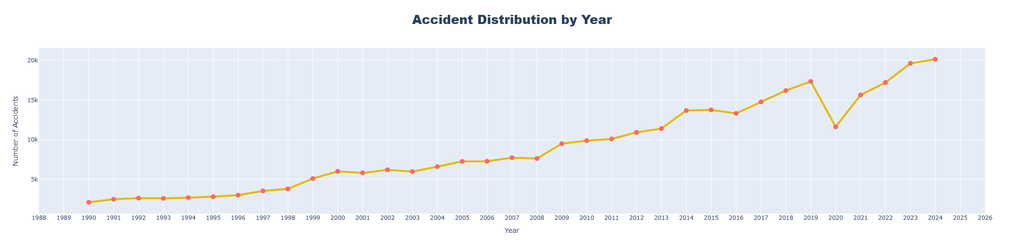

2.1.1 — plot_2-1-1.png

```python
year_counts = aws.groupby("INCIDENT_YEAR").size().reset_index(name="Accidents")
fig1 = px.line(
    year_counts,
    x="INCIDENT_YEAR",
    y="Accidents",
    markers=True,
    title="Accident Distribution by Year",
    labels={"INCIDENT_YEAR": "Year", "Accidents": "Number of Accidents"}
)
fig1.update_layout(title_font_size=26, title_font_family="Arial Black", title_x=0.5)
fig1.update_xaxes(tickmode='linear')
fig1.update_traces(line=dict(width=4, color="#E6B800"), marker=dict(size=10, color="#ff6666"))
fig1.show()
```

*Accident Distribution by Year*

- Passenger flight numbers increased over the period, but the growth is less pronounced than the surge in recorded accidents.
- This discrepancy may indicate changes in reporting practices or approaches.
- The hypothesis can be further verified with an additional chart.

#### 2.1.2 - Annual Proportion of Accidents with Indicated Damage

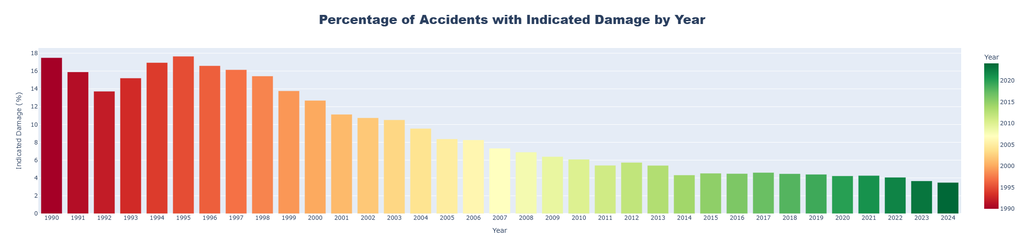

2.1.2 — plot_2-1-2.png

```python
year_total = aws.groupby("INCIDENT_YEAR").size().reset_index(name="Total_Incidents")
year_damage = aws[aws["INDICATED_DAMAGE"] == 1].groupby("INCIDENT_YEAR").size().reset_index(name="Damage_Incidents")
merged = pd.merge(year_total, year_damage, on="INCIDENT_YEAR", how="left").fillna(0)
merged["Damage_Pct"] = (merged["Damage_Incidents"] / merged["Total_Incidents"]) * 100
fig2 = px.bar(
    merged,
    x="INCIDENT_YEAR",
    y="Damage_Pct",
    color="INCIDENT_YEAR",
    title="Percentage of Accidents with Indicated Damage by Year",
    labels={"INCIDENT_YEAR": "Year", "Damage_Pct": "Indicated Damage (%)"},
    color_continuous_scale="RdYlGn"
)
fig2.update_layout(
    title_font_size=26,
    title_font_family="Arial Black",
    title_x=0.5,
    xaxis=dict(tickmode='linear')
)
fig2.show()
```

*Annual Proportion of Accidents with Indicated Damage*

- The trends observed in the annual accident distribution are confirmed.
- The lower proportion of incidents with indicated damage might also be a result of enhanced aircraft safety measures.

#### 2.1.3 - Accident Distribution by Month

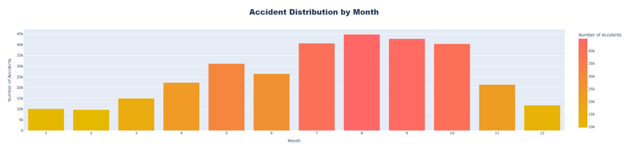

2.1.3 — plot_2-1-3.png

```python
accidents_by_month = aws.groupby("INCIDENT_MONTH").size().reset_index(name="Accidents")
accidents_by_month = accidents_by_month.sort_values("INCIDENT_MONTH")
fig3 = px.bar(
    accidents_by_month,
    x="INCIDENT_MONTH",
    y="Accidents",
    title="Accident Distribution by Month",
    labels={"INCIDENT_MONTH": "Month", "Accidents": "Number of Accidents"},
    color="Accidents",
    color_continuous_scale=[(0.0, "#E6B800"), (1.0, "#ff6666")]
)
fig3.update_layout(
    title_font_size=26,
    title_font_family="Arial Black",
    title_x=0.5,
    xaxis=dict(tickmode='linear', tick0=1, dtick=1)
)
fig3.show()
```

*Accident Distribution by Month*

The monthly distribution of accidents shows a clear seasonal pattern, porbably based on birds habits.

### 2.2 - Bird SPECIES Analysis

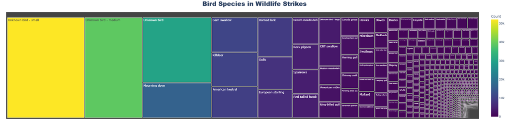

2.2 — plot_2-2.png

```python
species_df = aws['SPECIES'].value_counts().reset_index()
species_df.columns = ['Species', 'Count']

fig = px.treemap(
    species_df,
    path=['Species'],
    values='Count',
    title='Bird Species in Wildlife Strikes',
    color='Count',
    color_continuous_scale='Viridis'
)

fig.update_layout(
    title_font_size=26,
    title_font_family="Arial Black",
    title_x=0.5,
    margin=dict(t=50, l=25, r=25, b=25)
)
fig.show()
```

*Bird Species Analysis*

- The treemap shows a wide range of species, with a large segment corresponding to unidentified or unspecified birds.
- Among the frequently reported species are gulls and doves, suggesting that airports in areas with high activity of these birds are particularly vulnerable to wildlife strikes.
- A significant portion of the available bird information is based solely on size; therefore, further analyses will focus on classifying birds by size rather than by species.

### 2.3 - AIRCRAFT Types Analysis

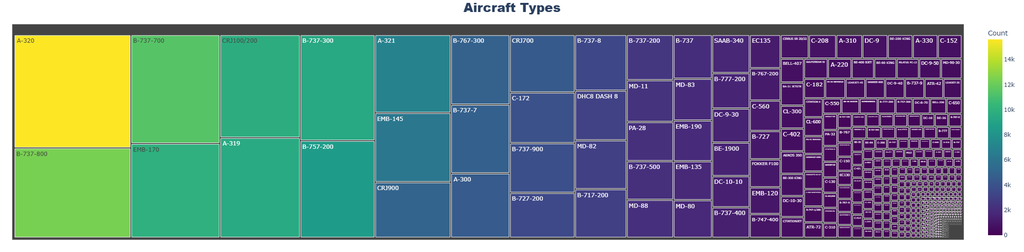

2.3 — plot_2-3.png

```python
aircraft_counts = aws['AIRCRAFT'].value_counts().reset_index()
aircraft_counts.columns = ['Aircraft', 'Count']

fig = px.treemap(
    aircraft_counts,
    path=['Aircraft'],
    values='Count',
    title='Aircraft Types',
    color='Count',
    color_continuous_scale='Viridis'
)
fig.update_layout(title_font_size=26, title_font_family="Arial Black", title_x=0.5,
                  margin=dict(t=50, l=25, r=25, b=25))
fig.show()
```

*Aircraft Types Analysis*

- The treemap reveals a broad array of aircraft models, with A320 and B737 being the most common. This is due to their widespread use in passenger aviation and their high prevalence in the airspace.
- In the subsequent study, the focus will be on aircraft parameters such as class, weight, and the number of engines. Where such information is missing, it will be supplemented using data from other entries for these aircraft.

### 2.4 - PHASE OF FLIGHT Analysis

#### 2.4.1 - Box Plots for HEIGHT, SPEED, and DISTANCE by PHASE OF FLIGHT

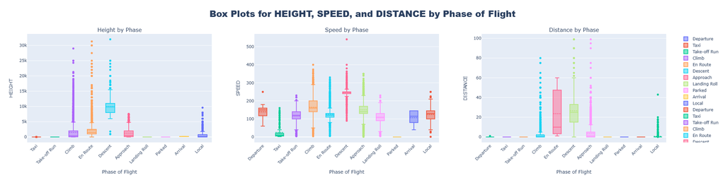

2.4.1 — plot_2-4-1.png

```python
phase_order = ["Departure", "Taxi", "Take-off Run", "Climb", "En Route", "Descent",
               "Approach", "Landing Roll", "Parked", "Arrival", "Local", "Unknown"]

fig = make_subplots(rows=1, cols=3,
                    subplot_titles=("Height by Phase", "Speed by Phase", "Distance by Phase"))
for i, col in enumerate(["HEIGHT", "SPEED", "DISTANCE"]):
    for phase in phase_order:
        data_phase = aws[aws["PHASE_OF_FLIGHT"] == phase]
        if not data_phase.empty:
            fig.add_trace(
                go.Box(y=data_phase[col], name=phase, boxmean=True, boxpoints="outliers"),
                row=1, col=i+1
            )
    fig.update_xaxes(title_text="Phase of Flight", tickangle=-45, row=1, col=i+1)
    fig.update_yaxes(title_text=col, row=1, col=i+1)

fig.update_layout(title_text="Box Plots for HEIGHT, SPEED, and DISTANCE by Phase of Flight",
                  title_font_size=26, title_font_family="Arial Black", title_x=0.5, showlegend=True)
fig.show()
```

[output not shown]

*Box Plots for HEIGHT, SPEED, and DISTANCE by Phase of Flight*

#### 2.4.2 - Total Accidents Distribution Across PHASE OF FLIGHT

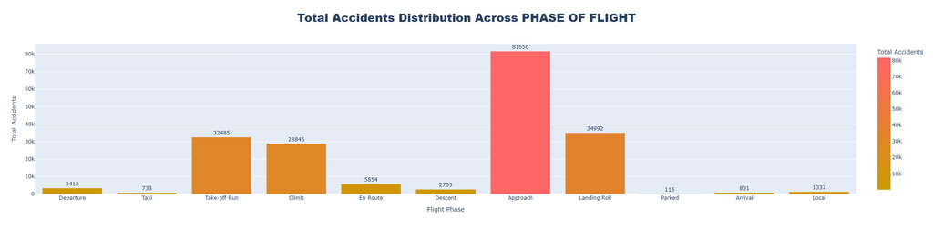

2.4.2 — plot_2-4-2.png

```python
phase_order = ["Departure", "Taxi", "Take-off Run", "Climb", "En Route", "Descent",
               "Approach", "Landing Roll", "Parked", "Arrival", "Local", "Unknown"]

phase_stats_total = aws.groupby("PHASE_OF_FLIGHT").size().reset_index(name="Total")
phase_stats_total["PHASE_OF_FLIGHT"] = pd.Categorical(phase_stats_total["PHASE_OF_FLIGHT"],
                                                       categories=phase_order,
                                                       ordered=True)
phase_stats_total.sort_values("PHASE_OF_FLIGHT", inplace=True)

fig_total = px.bar(
    phase_stats_total,
    x="PHASE_OF_FLIGHT",
    y="Total",
    text="Total",
    labels={"PHASE_OF_FLIGHT": "Flight Phase", "Total": "Total Accidents"},
    title="Total Accidents Distribution Across PHASE OF FLIGHT",
    color="Total",
    color_continuous_scale=["#cc9900", "#ff6666"]
)
fig_total.update_traces(texttemplate="%{text}", textposition="outside")
fig_total.update_layout(title_font_size=26, title_font_family="Arial Black", title_x=0.5)
fig_total.show()
```

*Total Accidents Distribution Across Flight Phases*

- The bar chart displays the total number of incidents for each flight phase. The highest counts occur in the "Approach" phase, likely due to the lower altitude and reduced speed near airports—a region frequently inhabited by birds.
- A significant number of incidents are also observed during the "Take-off Run", "Climb" and " Landing Roll" phases, where rapid altitude changes elevate the risk of bird strikes.
- Notably, the main cruise phases ("En Route" and "Descent") shows a low incident count, probably because aircraft operate at altitudes that are generally too high for most birds.

### 2.5 - INDICATED DAMAGES Distribution Analysis

#### 2.5.1 - Percent of INDICATED DAMAGES Distribution Across PHASE OF FLIGHT

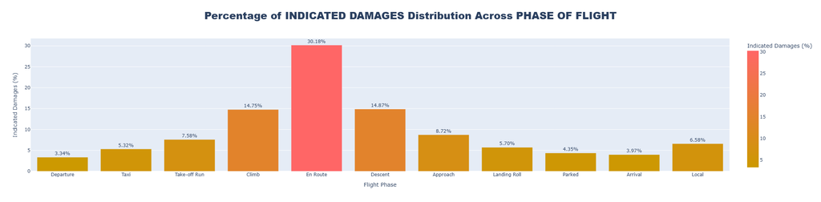

2.5.1 — plot_2-5-1.png

```python
phase_order = ["Departure", "Taxi", "Take-off Run", "Climb", "En Route", "Descent",
               "Approach", "Landing Roll", "Parked", "Arrival", "Local", "Unknown"]

phase_stats = aws.groupby("PHASE_OF_FLIGHT", observed=True)["INDICATED_DAMAGE"]\
                 .agg(total='count', damage='sum').reset_index()
phase_stats["Damage_Pct"] = (phase_stats["damage"] / phase_stats["total"]) * 100
phase_stats["PHASE_OF_FLIGHT"] = pd.Categorical(phase_stats["PHASE_OF_FLIGHT"],
                                                categories=phase_order,
                                                ordered=True)
phase_stats.sort_values("PHASE_OF_FLIGHT", inplace=True)

fig_phase = px.bar(
    phase_stats,
    x="PHASE_OF_FLIGHT",
    y="Damage_Pct",
    text="Damage_Pct",
    labels={"PHASE_OF_FLIGHT": "Flight Phase", "Damage_Pct": "Indicated Damages (%)"},
    title="Percentage of INDICATED DAMAGES Distribution Across PHASE OF FLIGHT",
    color="Damage_Pct",
    color_continuous_scale=["#cc9900", "#ff6666"]
)
fig_phase.update_traces(texttemplate="%{text:.2f}%", textposition="outside")
fig_phase.update_layout(title_font_size=26, title_font_family="Arial Black", title_x=0.5)
fig_phase.show()
```

*Percent of INDICATED DAMAGES Distribution Across PHASE OF FLIGHT*

#### 2.5.2 - Percent of INDICATED DAMAGES Distribution by HEIGHT

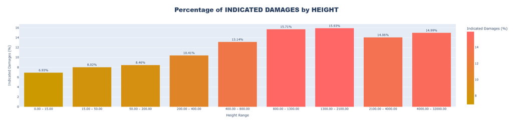

2.5.2 — plot_2-5-2.png

```python
df_h = aws.dropna(subset=["HEIGHT", "INDICATED_DAMAGE"]).copy()
bins = pd.qcut(df_h["HEIGHT"], q=15, duplicates="drop", retbins=True)[1]
labels = [f"{bins[i]:.2f} – {bins[i+1]:.2f}" for i in range(len(bins)-1)]
df_h["Height_Range"] = pd.qcut(df_h["HEIGHT"], q=15, labels=labels, duplicates="drop")
agg = df_h.groupby("Height_Range")["INDICATED_DAMAGE"].agg(total='count', damage='sum').reset_index()
agg["Damage_Pct"] = (agg["damage"] / agg["total"]) * 100

fig_height = px.bar(
    agg,
    x="Height_Range",
    y="Damage_Pct",
    text="Damage_Pct",
    labels={"Height_Range": "Height Range", "Damage_Pct": "Indicated Damages (%)"},
    title="Percentage of INDICATED DAMAGES by HEIGHT",
    color="Damage_Pct",
    color_continuous_scale=["#cc9900", "#ff6666"]
)
fig_height.update_layout(title_font_size=26, title_font_family="Arial Black", title_x=0.5)
fig_height.update_traces(texttemplate="%{text:.2f}%", textposition="outside")
fig_height.show()
```

*Percentage of INDICATED DAMAGES by HEIGHT*

#### 2.5.3 - Percent of INDICATED DAMAGES Distribution by SPEED

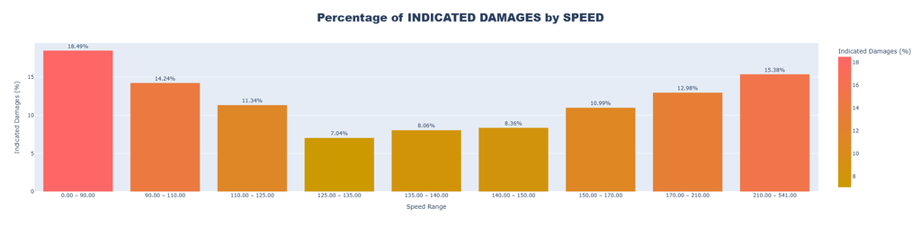

2.5.3 — plot_2-5-3.png

```python
df_s = aws.dropna(subset=["SPEED", "INDICATED_DAMAGE"]).copy()
bins_s = pd.qcut(df_s["SPEED"], q=9, duplicates="drop", retbins=True)[1]
labels_s = [f"{bins_s[i]:.2f} – {bins_s[i+1]:.2f}" for i in range(len(bins_s)-1)]
df_s["Speed_Range"] = pd.qcut(df_s["SPEED"], q=9, labels=labels_s, duplicates="drop")
agg_s = df_s.groupby("Speed_Range")["INDICATED_DAMAGE"].agg(total='count', damage='sum').reset_index()
agg_s["Damage_Pct"] = (agg_s["damage"] / agg_s["total"]) * 100

fig_speed = px.bar(
    agg_s,
    x="Speed_Range",
    y="Damage_Pct",
    text="Damage_Pct",
    labels={"Speed_Range": "Speed Range", "Damage_Pct": "Indicated Damages (%)"},
    title="Percentage of INDICATED DAMAGES by SPEED",
    color="Damage_Pct",
    color_continuous_scale=["#cc9900", "#ff6666"]
)
fig_speed.update_layout(title_font_size=26, title_font_family="Arial Black", title_x=0.5)
fig_speed.update_traces(texttemplate="%{text:.2f}%", textposition="outside")
fig_speed.show()
```

*Percentage of INDICATED DAMAGES by SPEED*

## **3 - Missing Data Imputation**

As part of filling in missing data, the following actions were planned:

- **Derive** **TIME_OF_DAY** from local sunrise/sunset, classifying each incident as Dawn, Day, Dusk or Night.
- **Impute** **DISTANCE** with the median for each phase of flight; **SPEED** and **HEIGHT** with the median for each (phase × aircraft class) group.
- **Label** missing **SKY** entries for night-time incidents as “NightSky.”
- **Collapse** **SIZE** into three categories (Small, Medium, Large), leaving any unknown sizes unchanged.
- **Drop** any rows that still contain missing values to ensure a complete dataset.

```python
summary_basic = pd.DataFrame({
    'Data type': aws.dtypes,
    'Non-null count': aws.notnull().sum(),
    'Null count': aws.isnull().sum(),
    'Null percentage': (aws.isnull().mean() * 100).round(2),
    'Unique count': aws.nunique(dropna=True)
}, index=aws.columns).T

display(summary_basic)
```

|  | INDICATED_DAMAGE | INCIDENT_YEAR | INCIDENT_MONTH | INCIDENT_DATE | TIME | TIME_OF_DAY | PHASE_OF_FLIGHT | HEIGHT | SPEED | DISTANCE | AIRCRAFT | AC_CLASS | AC_MASS | TYPE_ENG | NUM_ENGS | SKY | SPECIES | SPECIES_ID | SIZE | NUM_STRUCK | AIRPORT_ID | AIRPORT | STATE | OPERATOR | FAAREGION |
| --- | --- | --- | --- | --- | --- | --- | --- | --- | --- | --- | --- | --- | --- | --- | --- | --- | --- | --- | --- | --- | --- | --- | --- | --- | --- |
| Data type | int64 | int64 | int64 | object | object | object | object | float64 | float64 | float64 | object | object | float64 | object | float64 | object | object | object | object | object | object | object | object | object | object |
| Non-null count | 316823 | 316823 | 316823 | 316823 | 194392 | 178083 | 192965 | 160041 | 100401 | 208005 | 226935 | 226542 | 226425 | 226061 | 226160 | 150769 | 316823 | 316823 | 286163 | 316148 | 275960 | 275966 | 275883 | 227215 | 275883 |
| Null count | 0 | 0 | 0 | 0 | 122431 | 138740 | 123858 | 156782 | 216422 | 108818 | 89888 | 90281 | 90398 | 90762 | 90663 | 166054 | 0 | 0 | 30660 | 675 | 40863 | 40857 | 40940 | 89608 | 40940 |
| Null percentage | 0.0 | 0.0 | 0.0 | 0.0 | 38.64 | 43.79 | 39.09 | 49.49 | 68.31 | 34.35 | 28.37 | 28.5 | 28.53 | 28.65 | 28.62 | 52.41 | 0.0 | 0.0 | 9.68 | 0.21 | 12.9 | 12.9 | 12.92 | 28.28 | 12.92 |
| Unique count | 2 | 35 | 12 | 12702 | 1441 | 4 | 11 | 724 | 290 | 226 | 612 | 5 | 5 | 7 | 4 | 3 | 929 | 929 | 3 | 4 | 2699 | 2705 | 67 | 617 | 10 |

### 3.1 - Imputation of TIME / TIME_OF_DAY

Due to a significant amount of missing entries in the time information, the decision was made to simplify this variable by focusing on "time of day" rather than the exact clock time. The rationale is as follows:

- The specific clock time can represent either day or night depending on factors such as the date and geographical location (latitude and altitude).
- The "time of day" information is critical both for detecting bird presence and for understanding birds' diurnal behavior, thereby providing more relevant insight than the exact time.
- Accordingly, the "time of day" variable will be derived for records that contain both time and airport information, by combining geolocation data with sun time calculations.

#### 3.1.1 – Summary of Missing Values in TIME and TIME_OF_DAY

```python
both = aws["TIME"].notnull() & aws["TIME_OF_DAY"].notnull()
time_only = aws["TIME"].notnull() & aws["TIME_OF_DAY"].isnull()
tod_only = aws["TIME"].isnull() & aws["TIME_OF_DAY"].notnull()
neither = aws["TIME"].isnull() & aws["TIME_OF_DAY"].isnull()

print("Records with both TIME and TIME_OF_DAY:", both.sum())
print("Records with TIME only:", time_only.sum())
print("Records with TIME_OF_DAY only:", tod_only.sum())
print("Records with neither TIME nor TIME_OF_DAY:", neither.sum())
```

```
Records with both TIME and TIME_OF_DAY: 142938
Records with TIME only: 51454
Records with TIME_OF_DAY only: 35145
Records with neither TIME nor TIME_OF_DAY: 87286
```

#### 3.1.2 – Extract Subset for TIME_OF_DAY Imputation

```python
subset_impute = aws[aws["TIME_OF_DAY"].isnull() & aws["TIME"].notnull() & aws["AIRPORT_ID"].notnull()].copy()
```

#### 3.1.3 – Retrieve Airport Coordinates for the Subset

```python
tf = TimezoneFinder()

airports_iata = load('IATA')
airports_icao = load('ICAO')

def get_airport_coords(code: str):
    """
    Returns (lat, lon) for code IATA/ICAO.
    """
    if pd.isna(code):
        return np.nan, np.nan

    code = str(code).strip().upper()
    rec = airports_iata.get(code) or airports_icao.get(code)
    if rec is None:
        return np.nan, np.nan

    return rec['lat'], rec['lon']

def fetch_coords(row):
    code = row["AIRPORT_ID"]
    lat, lon = get_airport_coords(code)
    return pd.Series([lat, lon], index=["LAT", "LON"])

subset_impute[["LAT", "LON"]] = subset_impute.apply(fetch_coords, axis=1)
subset_impute = subset_impute.dropna(subset=["LAT", "LON"])
display(subset_impute[["INCIDENT_DATE", "TIME", "TIME_OF_DAY", "AIRPORT_ID", "AIRPORT", "LAT", "LON"]].head())
```

|  | INCIDENT_DATE | TIME | TIME_OF_DAY | AIRPORT_ID | AIRPORT | LAT | LON |
| --- | --- | --- | --- | --- | --- | --- | --- |
| 1782 | 1991-10-22 | 06:45 | NaN | KDBQ | DUBUQUE REGIONAL ARPT | 42.40200 | -90.70947 |
| 8503 | 1993-12-26 | 19:00 | NaN | KLGA | LA GUARDIA ARPT | 40.77725 | -73.87261 |
| 11986 | 1998-12-14 | 17:07 | NaN | KEUG | MAHLON SWEET FLD | 44.12458 | -123.21197 |
| 13945 | 1998-01-21 | 17:45 | NaN | KSMF | SACRAMENTO INTL | 38.69544 | -121.59078 |
| 16314 | 1999-10-14 | 21:55 | NaN | KBIL | BILLINGS LOGAN INTL | 45.80785 | -108.54354 |

#### 3.1.4 – Compute Sun Times Based on Geolocation

```python
def compute_sun_times_local(row):
    try:
        lat = float(row["LAT"])
        lon = float(row["LON"])
    except Exception:
        return pd.Series([np.nan, np.nan, np.nan, np.nan], index=["Dawn", "Sunrise", "Sunset", "Dusk"])
    try:
        inc_date = datetime.strptime(row["INCIDENT_DATE"], "%Y-%m-%d")
    except Exception:
        return pd.Series([np.nan, np.nan, np.nan, np.nan], index=["Dawn", "Sunrise", "Sunset", "Dusk"])
    tz_str = tf.timezone_at(lat=lat, lng=lon) or "UTC"
    local_tz = pytz.timezone(tz_str)
    loc = LocationInfo(name="Airport", region="", timezone=tz_str, latitude=lat, longitude=lon)
    try:
        s = sun(loc.observer, date=inc_date, tzinfo=local_tz)
        dawn = s.get("dawn").strftime("%H:%M") if s.get("dawn") else np.nan
        sunrise = s.get("sunrise").strftime("%H:%M") if s.get("sunrise") else np.nan
        sunset = s.get("sunset").strftime("%H:%M") if s.get("sunset") else np.nan
        dusk = s.get("dusk").strftime("%H:%M") if s.get("dusk") else np.nan
    except Exception:
        dawn, sunrise, sunset, dusk = np.nan, np.nan, np.nan, np.nan
    return pd.Series([dawn, sunrise, sunset, dusk], index=["Dawn", "Sunrise", "Sunset", "Dusk"])

time_airport_local = subset_impute.copy()
time_airport_local[["Dawn", "Sunrise", "Sunset", "Dusk"]] = time_airport_local.apply(compute_sun_times_local, axis=1)
display(time_airport_local[["INCIDENT_DATE", "TIME", "AIRPORT_ID", "LAT", "LON", "Dawn", "Sunrise", "Sunset", "Dusk"]].head())
```

|  | INCIDENT_DATE | TIME | AIRPORT_ID | LAT | LON | Dawn | Sunrise | Sunset | Dusk |
| --- | --- | --- | --- | --- | --- | --- | --- | --- | --- |
| 1782 | 1991-10-22 | 06:45 | KDBQ | 42.40200 | -90.70947 | 06:54 | 07:23 | 18:10 | 18:39 |
| 8503 | 1993-12-26 | 19:00 | KLGA | 40.77725 | -73.87261 | 06:47 | 07:18 | 16:33 | 17:05 |
| 11986 | 1998-12-14 | 17:07 | KEUG | 44.12458 | -123.21197 | 07:06 | 07:40 | 16:34 | 17:08 |
| 13945 | 1998-01-21 | 17:45 | KSMF | 38.69544 | -121.59078 | 06:51 | 07:20 | 17:15 | 17:44 |
| 16314 | 1999-10-14 | 21:55 | KBIL | 45.80785 | -108.54354 | 06:58 | 07:29 | 18:30 | 19:00 |

#### 3.1.5 – Compute Extended Time Boundaries

```python
def compute_extended_boundaries_new(row):
    base_date = "1900-01-01 "
    try:
        dawn_dt = datetime.strptime(base_date + str(row["Dawn"]).strip(), "%Y-%m-%d %H:%M")
        sunrise_dt = datetime.strptime(base_date + str(row["Sunrise"]).strip(), "%Y-%m-%d %H:%M")
        sunset_dt = datetime.strptime(base_date + str(row["Sunset"]).strip(), "%Y-%m-%d %H:%M")
        dusk_dt = datetime.strptime(base_date + str(row["Dusk"]).strip(), "%Y-%m-%d %H:%M")
    except Exception:
        return pd.Series([np.nan, np.nan], index=["Dawn_End", "Dusk_Begin"])
    diff_dawn = sunrise_dt - dawn_dt
    diff_dusk = dusk_dt - sunset_dt
    dawn_end = sunrise_dt + diff_dawn
    dusk_begin = sunset_dt - diff_dusk
    return pd.Series([dawn_end.strftime("%H:%M"), dusk_begin.strftime("%H:%M")], index=["Dawn_End", "Dusk_Begin"])

time_airport_local[["Dawn_End", "Dusk_Begin"]] = time_airport_local.apply(compute_extended_boundaries_new, axis=1)
display(time_airport_local[["INCIDENT_DATE", "TIME", "AIRPORT_ID", "Dawn", "Sunrise", "Dawn_End", "Dusk_Begin", "Sunset", "Dusk"]].head())
```

|  | INCIDENT_DATE | TIME | AIRPORT_ID | Dawn | Sunrise | Dawn_End | Dusk_Begin | Sunset | Dusk |
| --- | --- | --- | --- | --- | --- | --- | --- | --- | --- |
| 1782 | 1991-10-22 | 06:45 | KDBQ | 06:54 | 07:23 | 07:52 | 17:41 | 18:10 | 18:39 |
| 8503 | 1993-12-26 | 19:00 | KLGA | 06:47 | 07:18 | 07:49 | 16:01 | 16:33 | 17:05 |
| 11986 | 1998-12-14 | 17:07 | KEUG | 07:06 | 07:40 | 08:14 | 16:00 | 16:34 | 17:08 |
| 13945 | 1998-01-21 | 17:45 | KSMF | 06:51 | 07:20 | 07:49 | 16:46 | 17:15 | 17:44 |
| 16314 | 1999-10-14 | 21:55 | KBIL | 06:58 | 07:29 | 08:00 | 18:00 | 18:30 | 19:00 |

#### 3.1.6 – Classify and Impute TIME_OF_DAY

```python
def classify_time_of_day_new(row):
    base_date = "1900-01-01 "
    try:
        rec_time = datetime.strptime(base_date + str(row["TIME"]).strip(), "%Y-%m-%d %H:%M")
        dawn_time = datetime.strptime(base_date + str(row["Dawn"]).strip(), "%Y-%m-%d %H:%M")
        dawn_end = datetime.strptime(base_date + str(row["Dawn_End"]).strip(), "%Y-%m-%d %H:%M")
        dusk_begin = datetime.strptime(base_date + str(row["Dusk_Begin"]).strip(), "%Y-%m-%d %H:%M")
        dusk_time = datetime.strptime(base_date + str(row["Dusk"]).strip(), "%Y-%m-%d %H:%M")
    except Exception:
        return np.nan
    if rec_time < dawn_time:
        return "Night"
    elif dawn_time <= rec_time < dawn_end:
        return "Dawn"
    elif dawn_end <= rec_time <= dusk_begin:
        return "Day"
    elif dusk_begin < rec_time <= dusk_time:
        return "Dusk"
    else:
        return "Night"

time_airport_local["TIME_OF_DAY"] = time_airport_local.apply(classify_time_of_day_new, axis=1)
display(time_airport_local[["INCIDENT_DATE", "TIME", "TIME_OF_DAY", "Dawn", "Sunrise", "Dawn_End", "Dusk_Begin", "Sunset", "Dusk"]].head())

aws.loc[time_airport_local.index, "TIME_OF_DAY"] = time_airport_local["TIME_OF_DAY"]
```

|  | INCIDENT_DATE | TIME | TIME_OF_DAY | Dawn | Sunrise | Dawn_End | Dusk_Begin | Sunset | Dusk |
| --- | --- | --- | --- | --- | --- | --- | --- | --- | --- |
| 1782 | 1991-10-22 | 06:45 | Night | 06:54 | 07:23 | 07:52 | 17:41 | 18:10 | 18:39 |
| 8503 | 1993-12-26 | 19:00 | Night | 06:47 | 07:18 | 07:49 | 16:01 | 16:33 | 17:05 |
| 11986 | 1998-12-14 | 17:07 | Dusk | 07:06 | 07:40 | 08:14 | 16:00 | 16:34 | 17:08 |
| 13945 | 1998-01-21 | 17:45 | Night | 06:51 | 07:20 | 07:49 | 16:46 | 17:15 | 17:44 |
| 16314 | 1999-10-14 | 21:55 | Night | 06:58 | 07:29 | 08:00 | 18:00 | 18:30 | 19:00 |

```python
summary_basic = pd.DataFrame({
    'Data type': aws.dtypes,
    'Non-null count': aws.notnull().sum(),
    'Null count': aws.isnull().sum(),
    'Null percentage': (aws.isnull().mean() * 100).round(2),
    'Unique count': aws.nunique(dropna=True)
}, index=aws.columns).T

display(summary_basic)
```

|  | INDICATED_DAMAGE | INCIDENT_YEAR | INCIDENT_MONTH | INCIDENT_DATE | TIME | TIME_OF_DAY | PHASE_OF_FLIGHT | HEIGHT | SPEED | DISTANCE | AIRCRAFT | AC_CLASS | AC_MASS | TYPE_ENG | NUM_ENGS | SKY | SPECIES | SPECIES_ID | SIZE | NUM_STRUCK | AIRPORT_ID | AIRPORT | STATE | OPERATOR | FAAREGION |
| --- | --- | --- | --- | --- | --- | --- | --- | --- | --- | --- | --- | --- | --- | --- | --- | --- | --- | --- | --- | --- | --- | --- | --- | --- | --- |
| Data type | int64 | int64 | int64 | object | object | object | object | float64 | float64 | float64 | object | object | float64 | object | float64 | object | object | object | object | object | object | object | object | object | object |
| Non-null count | 316823 | 316823 | 316823 | 316823 | 194392 | 206561 | 192965 | 160041 | 100401 | 208005 | 226935 | 226542 | 226425 | 226061 | 226160 | 150769 | 316823 | 316823 | 286163 | 316148 | 275960 | 275966 | 275883 | 227215 | 275883 |
| Null count | 0 | 0 | 0 | 0 | 122431 | 110262 | 123858 | 156782 | 216422 | 108818 | 89888 | 90281 | 90398 | 90762 | 90663 | 166054 | 0 | 0 | 30660 | 675 | 40863 | 40857 | 40940 | 89608 | 40940 |
| Null percentage | 0.0 | 0.0 | 0.0 | 0.0 | 38.64 | 34.8 | 39.09 | 49.49 | 68.31 | 34.35 | 28.37 | 28.5 | 28.53 | 28.65 | 28.62 | 52.41 | 0.0 | 0.0 | 9.68 | 0.21 | 12.9 | 12.9 | 12.92 | 28.28 | 12.92 |
| Unique count | 2 | 35 | 12 | 12702 | 1441 | 4 | 11 | 724 | 290 | 226 | 612 | 5 | 5 | 7 | 4 | 3 | 929 | 929 | 3 | 4 | 2699 | 2705 | 67 | 617 | 10 |

### 3.2 - Imputation of AIRCRAFT / AC_CLASS + AC_MASS + TYPE_ENG + NUM_ENGS

Information about the parameters of the aircraft is missing

- Need to check if it is possible to retrieve aircraft parameters using the information assigned to the model from another event

```python
missing_ac_class = aws[aws["AC_CLASS"].isnull() & aws["AIRCRAFT"].notnull()]

aircraft_counts = missing_ac_class["AIRCRAFT"].value_counts(dropna=False)

print("Unique values in 'AIRCRAFT' with missing 'AC_CLASS' value and their counts:")
print(aircraft_counts)
```

```
Unique values in 'AIRCRAFT' with missing 'AC_CLASS' value and their counts:
AIRCRAFT
EXPERIMENTAL             330
MILITARY                  29
DRONE                     28
Unknown                    1
BOMBARDIER                 1
CL-600-2C10 / CRJ 700      1
B767-200                   1
AW139                      1
Embraer 175                1
Name: count, dtype: int64
```

It turns out that the rows with missing information on the aricraft parameter are due to unusual and repetitive types of aircraft, and it is impossible to complete this data

### 3.3 - Imputation of PHASE_OF_FLIGHT + AC_CLASS / DISTANCE + HEIGHT + SPEED

Large deficiencies in flight parameters

- Need to see if it is possible to determine DISTANCE based on PHASE_OF_FLIGHT and vice versa
- It is also necessary to try to determine HEIGHT and SPEED on the PHASE_OF_FLIGHT and AC_CLASS substrate

```python
# --- Completing DISTANCE ---
mask_missing = aws["PHASE_OF_FLIGHT"].notnull() & aws["DISTANCE"].isnull()
missing_before = mask_missing.sum()
total_records = len(aws)

print(f"Before imputation: {missing_before} missing values out of {total_records} records.")

median_distance = aws.loc[aws["DISTANCE"].notnull()].groupby("PHASE_OF_FLIGHT")["DISTANCE"].median()

aws_filled = aws.copy()
aws_filled.loc[mask_missing, "DISTANCE"] = aws_filled.loc[mask_missing, "PHASE_OF_FLIGHT"].map(median_distance)

mask_missing_after = aws_filled["PHASE_OF_FLIGHT"].notnull() & aws_filled["DISTANCE"].isnull()
missing_after = mask_missing_after.sum()

imputed = missing_before - missing_after

print(f"After imputation: {missing_after} missing values out of {total_records} records.")
print(f"Number of values imputed: {imputed}")

aws = aws_filled.copy()
```

```
Before imputation: 73175 missing values out of 316823 records.
After imputation: 0 missing values out of 316823 records.
Number of values imputed: 73175
```

```python
# --- Completing  HEIGHT and SPEED ---
aws_imputed = aws.copy()

mask_speed = aws_imputed["PHASE_OF_FLIGHT"].notnull() & aws_imputed["AC_CLASS"].notnull() & aws_imputed["SPEED"].isnull()
median_speed = aws_imputed.groupby(["PHASE_OF_FLIGHT", "AC_CLASS"])["SPEED"].transform("median")
aws_imputed.loc[mask_speed, "SPEED"] = median_speed[mask_speed]

mask_height = aws_imputed["PHASE_OF_FLIGHT"].notnull() & aws_imputed["AC_CLASS"].notnull() & aws_imputed["HEIGHT"].isnull()
median_height = aws_imputed.groupby(["PHASE_OF_FLIGHT", "AC_CLASS"])["HEIGHT"].transform("median")

aws_imputed.loc[mask_height, "HEIGHT"] = median_height[mask_height]
total_records = len(aws)

speed_missing_before = aws["SPEED"].isnull().sum()
speed_missing_after  = aws_imputed["SPEED"].isnull().sum()
height_missing_before = aws["HEIGHT"].isnull().sum()
height_missing_after  = aws_imputed["HEIGHT"].isnull().sum()

imputed_speed  = speed_missing_before - speed_missing_after
imputed_height = height_missing_before - height_missing_after

print("=== SPEED Imputation Summary ===")
print(f"SPEED missing before imputation: {speed_missing_before}")
print(f"SPEED missing after imputation:  {speed_missing_after}")
print(f"Number of SPEED values imputed:  {imputed_speed}")
print("\n=== HEIGHT Imputation Summary ===")
print(f"HEIGHT missing before imputation: {height_missing_before}")
print(f"HEIGHT missing after imputation:  {height_missing_after}")
print(f"Number of HEIGHT values imputed:  {imputed_height}")

aws = aws_imputed.copy()
```

```
=== SPEED Imputation Summary ===
SPEED missing before imputation: 216422
SPEED missing after imputation:  125210
Number of SPEED values imputed:  91212

=== HEIGHT Imputation Summary ===
HEIGHT missing before imputation: 156782
HEIGHT missing after imputation:  127504
Number of HEIGHT values imputed:  29278
```

```python
summary_basic = pd.DataFrame({
    'Data type': aws.dtypes,
    'Non-null count': aws.notnull().sum(),
    'Null count': aws.isnull().sum(),
    'Null percentage': (aws.isnull().mean() * 100).round(2),
    'Unique count': aws.nunique(dropna=True)
}, index=aws.columns).T

display(summary_basic)
```

|  | INDICATED_DAMAGE | INCIDENT_YEAR | INCIDENT_MONTH | INCIDENT_DATE | TIME | TIME_OF_DAY | PHASE_OF_FLIGHT | HEIGHT | SPEED | DISTANCE | AIRCRAFT | AC_CLASS | AC_MASS | TYPE_ENG | NUM_ENGS | SKY | SPECIES | SPECIES_ID | SIZE | NUM_STRUCK | AIRPORT_ID | AIRPORT | STATE | OPERATOR | FAAREGION |
| --- | --- | --- | --- | --- | --- | --- | --- | --- | --- | --- | --- | --- | --- | --- | --- | --- | --- | --- | --- | --- | --- | --- | --- | --- | --- |
| Data type | int64 | int64 | int64 | object | object | object | object | float64 | float64 | float64 | object | object | float64 | object | float64 | object | object | object | object | object | object | object | object | object | object |
| Non-null count | 316823 | 316823 | 316823 | 316823 | 194392 | 206561 | 192965 | 189319 | 191613 | 281180 | 226935 | 226542 | 226425 | 226061 | 226160 | 150769 | 316823 | 316823 | 286163 | 316148 | 275960 | 275966 | 275883 | 227215 | 275883 |
| Null count | 0 | 0 | 0 | 0 | 122431 | 110262 | 123858 | 127504 | 125210 | 35643 | 89888 | 90281 | 90398 | 90762 | 90663 | 166054 | 0 | 0 | 30660 | 675 | 40863 | 40857 | 40940 | 89608 | 40940 |
| Null percentage | 0.0 | 0.0 | 0.0 | 0.0 | 38.64 | 34.8 | 39.09 | 40.24 | 39.52 | 11.25 | 28.37 | 28.5 | 28.53 | 28.65 | 28.62 | 52.41 | 0.0 | 0.0 | 9.68 | 0.21 | 12.9 | 12.9 | 12.92 | 28.28 | 12.92 |
| Unique count | 2 | 35 | 12 | 12702 | 1441 | 4 | 11 | 725 | 290 | 226 | 612 | 5 | 5 | 7 | 4 | 3 | 929 | 929 | 3 | 4 | 2699 | 2705 | 67 | 617 | 10 |

### 3.4 - Imputation of SIZE / SPECIES + SPECIES_ID

There's a big divide over how and how accurately to report on bird species and size

- For this reason, this information was limited to 3 paramaters in the SIZE category and was attempted to be completed based on the SPECIES and SPECIES_ID columns

```python
missing_by_species = aws[aws["SIZE"].isnull() & aws["SPECIES"].notnull()]
missing_counts = missing_by_species.groupby("SPECIES").size().reset_index(name="Missing_Count")
missing_counts_sorted = missing_counts.sort_values("Missing_Count", ascending=False)

print("Bird species with SIZE deficiencies and the number of such cases:")
display(missing_counts_sorted)
```

```
Bird species with SIZE deficiencies and the number of such cases:
```

|  | SPECIES | Missing_Count |
| --- | --- | --- |
| 0 | Unknown bird | 30217 |
| 1 | Unknown bird or bat | 398 |
| 2 | Unknown terrestial mammal | 45 |

It turns out that there is no way to complete the size information based on a column from SPECIES, but still the SIZE column was used as a form of describing the type of bird

### 3.5 - Imputation of SKY / TIME_OF_DAY / AIRPORT + TIME

There are very large deficiencies in the category that defines visibility (SKY).

- There is no way to complete these values except overnight (python libraries or external APIs available contain information from the last 5-10 years do not offer adequate accuracy or are based on predictive models without real information)
- It can be assumed that visibility at night is worse than during the day, even on a cloudy day, so we can add a new category “NightSky” for those events that took place at night and thus fill in some of the empty values

```python
mask_night = (aws["TIME_OF_DAY"] == "Night")
aws.loc[mask_night, "SKY"] = "NightSky"
```

### 3.6 - Features Filtering

```python
cols_to_keep = [
    "INDICATED_DAMAGE",
    "INCIDENT_YEAR",
    "INCIDENT_MONTH",
    #"INCIDENT_DATE",
    "TIME_OF_DAY",
    "HEIGHT",
    "SPEED",
    "DISTANCE",
    "AC_CLASS",
    "AC_MASS",
    "TYPE_ENG",
    "NUM_ENGS",
    "SKY",
    "SIZE",
    "NUM_STRUCK"
]

aws_f = aws[cols_to_keep].copy()
display(aws_f.head())
```

|  | INDICATED_DAMAGE | INCIDENT_YEAR | INCIDENT_MONTH | TIME_OF_DAY | HEIGHT | SPEED | DISTANCE | AC_CLASS | AC_MASS | TYPE_ENG | NUM_ENGS | SKY | SIZE | NUM_STRUCK |
| --- | --- | --- | --- | --- | --- | --- | --- | --- | --- | --- | --- | --- | --- | --- |
| 0 | 0 | 1996 | 6 | NaN | 0.0 | 120.0 | 0.0 | A | 4.0 | D | 2.0 | NaN | Medium | 1 |
| 1 | 0 | 1996 | 6 | NaN | 0.0 | 120.0 | 0.0 | A | 4.0 | D | 2.0 | NaN | Medium | 1 |
| 2 | 0 | 1996 | 7 | NaN | 0.0 | 120.0 | 0.0 | A | 4.0 | D | 2.0 | NaN | Medium | 1 |
| 3 | 0 | 1996 | 7 | NaN | 1000.0 | 140.0 | 1.0 | A | 4.0 | D | 2.0 | NaN | Medium | 1 |
| 4 | 1 | 1996 | 7 | NaN | 5000.0 | 160.0 | 0.0 | A | 4.0 | D | 2.0 | NaN | Medium | 1 |

### 3.7 - Conclusions

```python
summary_basic = pd.DataFrame({
    'Data type': aws_f.dtypes,
    'Non-null count': aws_f.notnull().sum(),
    'Null count': aws_f.isnull().sum(),
    'Null percentage': (aws_f.isnull().mean() * 100).round(2),
    'Unique count': aws_f.nunique(dropna=True)
}, index=aws_f.columns).T

display(summary_basic)
```

|  | INDICATED_DAMAGE | INCIDENT_YEAR | INCIDENT_MONTH | TIME_OF_DAY | HEIGHT | SPEED | DISTANCE | AC_CLASS | AC_MASS | TYPE_ENG | NUM_ENGS | SKY | SIZE | NUM_STRUCK |
| --- | --- | --- | --- | --- | --- | --- | --- | --- | --- | --- | --- | --- | --- | --- |
| Data type | int64 | int64 | int64 | object | float64 | float64 | float64 | object | float64 | object | float64 | object | object | object |
| Non-null count | 316823 | 316823 | 316823 | 206561 | 189319 | 191613 | 281180 | 226542 | 226425 | 226061 | 226160 | 166684 | 286163 | 316148 |
| Null count | 0 | 0 | 0 | 110262 | 127504 | 125210 | 35643 | 90281 | 90398 | 90762 | 90663 | 150139 | 30660 | 675 |
| Null percentage | 0.0 | 0.0 | 0.0 | 34.8 | 40.24 | 39.52 | 11.25 | 28.5 | 28.53 | 28.65 | 28.62 | 47.39 | 9.68 | 0.21 |
| Unique count | 2 | 35 | 12 | 4 | 725 | 290 | 226 | 5 | 5 | 7 | 4 | 4 | 3 | 4 |

```python
complete_rows = aws_f.dropna().shape[0]
print("Number of rows with complete data:", complete_rows)

total_rows = aws_f.shape[0]
complete_percentage = (complete_rows / total_rows) * 100
print("Percentage of rows with complete data: {:.2f}%".format(complete_percentage))

aws = aws_f.dropna()
```

```
Number of rows with complete data: 140015
Percentage of rows with complete data: 44.19%
```

## **4 - Data Preparation**

After cleaning the file and filling in the missing values, the dataset still needs a few technical steps before training the models:

- **Standardise text fields** (e.g., `AC_CLASS`) and trim extra spaces
- **Convert atypical entries** (e.g., `NUM_STRUCK`) to numeric form
- **Encode categories** (`TIME_OF_DAY`, `AC_CLASS`, `SKY`, `SIZE`) as integers
- **Apply one-hot encoding** to the multi-class field `TYPE_ENG`
- **Cast all numeric columns** to `int64` where possible
- **Convert the event month** (`INCIDENT_MONTH`) to sine-cosine cyclic codes
- **Review basic statistics and distributions** after all preparatory edits
- **Split the data** into 80 % training and 20 % test sets with class balance preserved (`train_test_split`)

### 4.1 - Initial Summary

#### 4.1.1 – Basic Summary

```python
summary_basic = pd.DataFrame({
    'Data type': aws.dtypes,
    'Non-null count': aws.notnull().sum(),
    'Null count': aws.isnull().sum(),
    'Null percentage': (aws.isnull().mean() * 100).round(2),
    'Unique count': aws.nunique(dropna=True)
}, index=aws.columns).T

display(summary_basic)
```

|  | INDICATED_DAMAGE | INCIDENT_YEAR | INCIDENT_MONTH | TIME_OF_DAY | HEIGHT | SPEED | DISTANCE | AC_CLASS | AC_MASS | TYPE_ENG | NUM_ENGS | SKY | SIZE | NUM_STRUCK |
| --- | --- | --- | --- | --- | --- | --- | --- | --- | --- | --- | --- | --- | --- | --- |
| Data type | int64 | int64 | int64 | object | float64 | float64 | float64 | object | float64 | object | float64 | object | object | object |
| Non-null count | 140015 | 140015 | 140015 | 140015 | 140015 | 140015 | 140015 | 140015 | 140015 | 140015 | 140015 | 140015 | 140015 | 140015 |
| Null count | 0 | 0 | 0 | 0 | 0 | 0 | 0 | 0 | 0 | 0 | 0 | 0 | 0 | 0 |
| Null percentage | 0.0 | 0.0 | 0.0 | 0.0 | 0.0 | 0.0 | 0.0 | 0.0 | 0.0 | 0.0 | 0.0 | 0.0 | 0.0 | 0.0 |
| Unique count | 2 | 35 | 12 | 4 | 642 | 284 | 211 | 2 | 5 | 5 | 4 | 4 | 3 | 4 |

#### 4.1.2 – DataFrame Head

```python
display(aws.head())
```

|  | INDICATED_DAMAGE | INCIDENT_YEAR | INCIDENT_MONTH | TIME_OF_DAY | HEIGHT | SPEED | DISTANCE | AC_CLASS | AC_MASS | TYPE_ENG | NUM_ENGS | SKY | SIZE | NUM_STRUCK |
| --- | --- | --- | --- | --- | --- | --- | --- | --- | --- | --- | --- | --- | --- | --- |
| 5 | 0 | 1991 | 5 | Day | 0.0 | 100.0 | 0.0 | A | 4.0 | D | 3.0 | No Cloud | Medium | 1 |
| 7 | 0 | 1990 | 9 | Day | 100.0 | 135.0 | 1.0 | A | 4.0 | D | 2.0 | Some Cloud | Small | 2-10 |
| 8 | 0 | 1992 | 5 | Day | 0.0 | 110.0 | 0.0 | A | 2.0 | C | 2.0 | Some Cloud | Small | 1 |
| 9 | 1 | 1990 | 8 | Night | 200.0 | 70.0 | 0.0 | A | 1.0 | A | 1.0 | NightSky | Large | 1 |
| 10 | 0 | 1990 | 9 | Day | 0.0 | 100.0 | 0.0 | A | 4.0 | D | 2.0 | No Cloud | Small | 2-10 |

### 4.2 - Data Preprocessing

#### 4.2.1 - Text Standardization

```python
aws.loc[:, 'AC_CLASS'] = aws['AC_CLASS'].astype(str).str.strip()
```

#### 4.2.2 - Parsing Unusual Values

```python
mapping_struck = {
    '1':               0,
    '2-10':            1,
    '11-100':          2,
    'More than 100':   3
}
aws.loc[:, 'NUM_STRUCK'] = (
    aws['NUM_STRUCK']
       .map(mapping_struck)
       .astype('Int64')
)
```

#### 4.2.3 - Converting Categories into Numerical Form

```python
cat_mappings = {
    'TIME_OF_DAY': {'Day': 0, 'Dawn': 1, 'Dusk': 2, 'Night': 3},
    'AC_CLASS':    {'A': 0, 'B': 1},
    'SKY':         {'No Cloud': 0, 'Some Cloud': 1, 'Overcast': 2, 'NightSky': 3},
    'SIZE':        {'Small': 0, 'Medium': 1, 'Large': 2}
}

for col, mp in cat_mappings.items():
    aws.loc[:, col] = aws[col].map(mp).astype('Int64')
    print(f"{col} → {mp}")
```

```
TIME_OF_DAY → {'Day': 0, 'Dawn': 1, 'Dusk': 2, 'Night': 3}
AC_CLASS → {'A': 0, 'B': 1}
SKY → {'No Cloud': 0, 'Some Cloud': 1, 'Overcast': 2, 'NightSky': 3}
SIZE → {'Small': 0, 'Medium': 1, 'Large': 2}
```

#### 4.2.4 - One-Hot Encoding for TYPE_ENG

```python
ohe_type = pd.get_dummies(aws['TYPE_ENG'], prefix='TYPE_ENG', dtype='int')
aws = pd.concat([aws, ohe_type], axis=1)
aws.drop(columns='TYPE_ENG', inplace=True)

summary_ohe = pd.DataFrame({
    'Count':      ohe_type.sum(),
    'Percentage': (ohe_type.sum() / len(ohe_type) * 100).round(2)
})
display(summary_ohe)
```

|  | Count | Percentage |
| --- | --- | --- |
| TYPE_ENG_A | 10886 | 7.77 |
| TYPE_ENG_B | 333 | 0.24 |
| TYPE_ENG_C | 11676 | 8.34 |
| TYPE_ENG_D | 113724 | 81.22 |
| TYPE_ENG_F | 3396 | 2.43 |

#### 4.2.5 - Setting a dtype as int

```python
float_cols = aws.select_dtypes(include=['float64']).columns
aws[float_cols] = aws[float_cols].round()

aws = aws.astype('int64')
```

#### 4.2.6 - Cyclical Encoding for INCIDENT_MONTH

```python
months = aws['INCIDENT_MONTH'].astype(int)

aws.loc[:, 'MONTH_SIN'] = np.sin(2 * np.pi * months / 12)
aws.loc[:, 'MONTH_COS'] = np.cos(2 * np.pi * months / 12)

aws.drop(columns='INCIDENT_MONTH', inplace=True)
```

### 4.3 - Final Verification

#### 4.3.1 – Basic Summary

```python
summary_basic = pd.DataFrame({
    'Data type': aws.dtypes,
    'Non-null count': aws.notnull().sum(),
    'Null count': aws.isnull().sum(),
    'Null percentage': (aws.isnull().mean() * 100).round(2),
    'Unique count': aws.nunique(dropna=True)
}, index=aws.columns).T

display(summary_basic)
```

|  | INDICATED_DAMAGE | INCIDENT_YEAR | TIME_OF_DAY | HEIGHT | SPEED | DISTANCE | AC_CLASS | AC_MASS | NUM_ENGS | SKY | SIZE | NUM_STRUCK | TYPE_ENG_A | TYPE_ENG_B | TYPE_ENG_C | TYPE_ENG_D | TYPE_ENG_F | MONTH_SIN | MONTH_COS |
| --- | --- | --- | --- | --- | --- | --- | --- | --- | --- | --- | --- | --- | --- | --- | --- | --- | --- | --- | --- |
| Data type | int64 | int64 | int64 | int64 | int64 | int64 | int64 | int64 | int64 | int64 | int64 | int64 | int64 | int64 | int64 | int64 | int64 | float64 | float64 |
| Non-null count | 140015 | 140015 | 140015 | 140015 | 140015 | 140015 | 140015 | 140015 | 140015 | 140015 | 140015 | 140015 | 140015 | 140015 | 140015 | 140015 | 140015 | 140015 | 140015 |
| Null count | 0 | 0 | 0 | 0 | 0 | 0 | 0 | 0 | 0 | 0 | 0 | 0 | 0 | 0 | 0 | 0 | 0 | 0 | 0 |
| Null percentage | 0.0 | 0.0 | 0.0 | 0.0 | 0.0 | 0.0 | 0.0 | 0.0 | 0.0 | 0.0 | 0.0 | 0.0 | 0.0 | 0.0 | 0.0 | 0.0 | 0.0 | 0.0 | 0.0 |
| Unique count | 2 | 35 | 4 | 642 | 284 | 57 | 2 | 5 | 4 | 4 | 3 | 4 | 2 | 2 | 2 | 2 | 2 | 11 | 11 |

#### 4.3.2 – DataFrame Head

```python
display(aws.head())
```

|  | INDICATED_DAMAGE | INCIDENT_YEAR | TIME_OF_DAY | HEIGHT | SPEED | DISTANCE | AC_CLASS | AC_MASS | NUM_ENGS | SKY | SIZE | NUM_STRUCK | TYPE_ENG_A | TYPE_ENG_B | TYPE_ENG_C | TYPE_ENG_D | TYPE_ENG_F | MONTH_SIN | MONTH_COS |
| --- | --- | --- | --- | --- | --- | --- | --- | --- | --- | --- | --- | --- | --- | --- | --- | --- | --- | --- | --- |
| 5 | 0 | 1991 | 0 | 0 | 100 | 0 | 0 | 4 | 3 | 0 | 1 | 0 | 0 | 0 | 0 | 1 | 0 | 0.500000 | -8.660254e-01 |
| 7 | 0 | 1990 | 0 | 100 | 135 | 1 | 0 | 4 | 2 | 1 | 0 | 1 | 0 | 0 | 0 | 1 | 0 | -1.000000 | -1.836970e-16 |
| 8 | 0 | 1992 | 0 | 0 | 110 | 0 | 0 | 2 | 2 | 1 | 0 | 0 | 0 | 0 | 1 | 0 | 0 | 0.500000 | -8.660254e-01 |
| 9 | 1 | 1990 | 3 | 200 | 70 | 0 | 0 | 1 | 1 | 3 | 2 | 0 | 1 | 0 | 0 | 0 | 0 | -0.866025 | -5.000000e-01 |
| 10 | 0 | 1990 | 0 | 0 | 100 | 0 | 0 | 4 | 2 | 0 | 0 | 1 | 0 | 0 | 0 | 1 | 0 | -1.000000 | -1.836970e-16 |

#### 4.3.3 – Distribution Plots

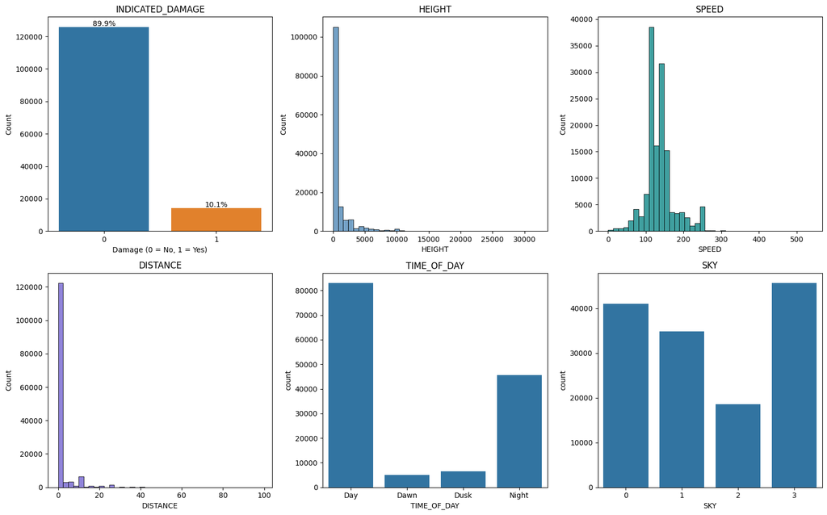

```python
plt.figure(figsize=(16,10))

# 1) INDICATED_DAMAGE
plt.subplot(2,3,1)
ax = sns.countplot(
    x='INDICATED_DAMAGE',
    hue='INDICATED_DAMAGE',
    data=aws,
    palette=['C0','C1'],
    legend=False
)
plt.title("INDICATED_DAMAGE")
plt.xlabel("Damage (0 = No, 1 = Yes)")
plt.ylabel("Count")

total = len(aws)
for p in ax.patches:
    count = p.get_height()
    pct = count / total * 100
    x = p.get_x() + p.get_width() / 2
    y = count + total * 0.005
    ax.text(x, y, f"{pct:.1f}%", ha='center')

# 2) HEIGHT
plt.subplot(2,3,2)
sns.histplot(aws['HEIGHT'], bins=40, color='steelblue')
plt.title("HEIGHT")

# 3) SPEED
plt.subplot(2,3,3)
sns.histplot(aws['SPEED'], bins=40, color='teal')
plt.title("SPEED")

# 4) DISTANCE
plt.subplot(2,3,4)
sns.histplot(aws['DISTANCE'], bins=40, color='slateblue')
plt.title("DISTANCE")

# 5) TIME_OF_DAY
plt.subplot(2,3,5)
labels = ['Day','Dawn','Dusk','Night']
sns.countplot(x='TIME_OF_DAY', data=aws)
plt.xticks(range(4), labels)
plt.title("TIME_OF_DAY")

# 6) SKY
plt.subplot(2,3,6)
sns.countplot(x='SKY', data=aws)
plt.title("SKY")

plt.tight_layout()
plt.show()
```

#### 4.3.4 – Correlation Heatmap

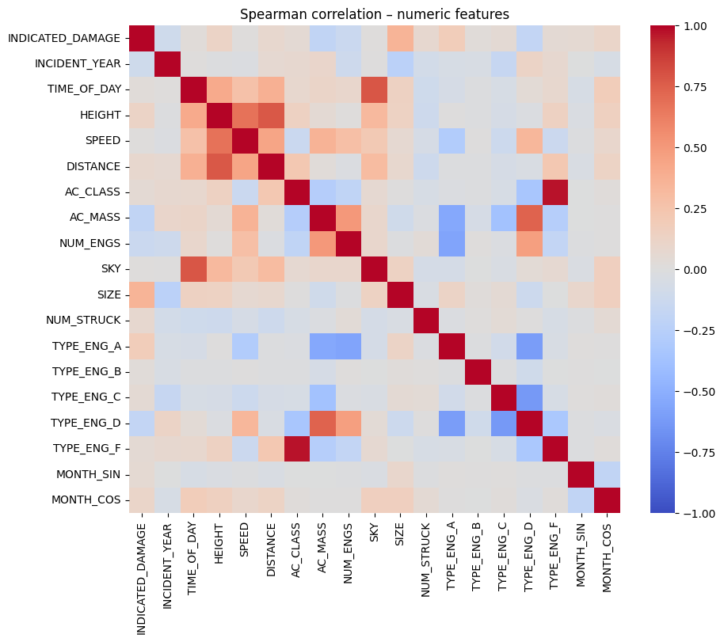

```python
num_cols = aws.select_dtypes(include=['int64','float64']).columns
plt.figure(figsize=(10,8))
sns.heatmap(aws[num_cols].corr(method='spearman'), cmap='coolwarm', vmin=-1, vmax=1)
plt.title("Spearman correlation – numeric features")
plt.show()
```

### 4.4 - Train/Test Split

```python
y = aws['INDICATED_DAMAGE']
X = aws.drop(columns='INDICATED_DAMAGE')

X_train, X_test, y_train, y_test = train_test_split(
    X, y,
    test_size=0.20,
    stratify=y,
    random_state=42
)

print("=== Train/Test Split (80/20)===",
      "\nX_train:", X_train.shape,
      "\ny_train pos:", y_train.sum(),
      "\nX_test:",  X_test.shape,
      "\ny_test pos:",  y_test.sum())
```

```
=== Train/Test Split (80/20)===
X_train: (112012, 18)
y_train pos: 11344
X_test: (28003, 18)
y_test pos: 2836
```

## **5 - Models Training**

In this section, the training of three classification models — Logistic Regression, Random Forest, and XGBoost — was carried out using two dataset variants: the original class distribution and the class-balanced version.

Before modeling, the data was transformed, and the hyperparameters were selected using Optuna (the tuning code is not included in this project).

### 5.1 - Transformations

```python
# 1) log1p for HEIGHT and DISTANCE
for col in ['HEIGHT', 'DISTANCE']:
    X_train[col] = np.log1p(X_train[col])
    X_test[col]  = np.log1p(X_test[col])

# 2) Train sets for Linear Model
num_cols = X_train.select_dtypes('number').columns
scaler   = RobustScaler().fit(X_train[num_cols])

X_train_lin = X_train.copy()
X_test_lin  = X_test.copy()
X_train_lin[num_cols] = scaler.transform(X_train_lin[num_cols])
X_test_lin[num_cols]  = scaler.transform(X_test_lin[num_cols])

# 3) Train sets for Tree Models
X_train_tree = X_train.copy()
X_test_tree  = X_test.copy()

print("Shapes  –  lin:", X_train_lin.shape, "| tree:", X_train_tree.shape)
```

```
Shapes  –  lin: (112012, 18) | tree: (112012, 18)
```

### 5.2 - Helpers

```python
cv = StratifiedKFold(5, shuffle=True, random_state=42)

def fit_model(model, X, y, tag):
    """Quick 5-fold snapshot (F1 / Prec / Rec)."""
    f1s, ps, rs = [], [], []
    for tr, va in tqdm(cv.split(X, y), total=5, desc=f"{tag} CV"):
        model.fit(X.iloc[tr], y.iloc[tr])
        p = model.predict(X.iloc[va])
        f1s.append(f1_score(y.iloc[va], p))
        ps.append(precision_score(y.iloc[va], p))
        rs.append(recall_score(y.iloc[va], p))
    print(f"{tag:<10} – F1 {np.mean(f1s):.3f}  P {np.mean(ps):.3f}  R {np.mean(rs):.3f}")

PRED = {}
```

### 5.3 - Models using the original distribution

#### 5.3.1 – Logistic Regression

```python
lr = LogisticRegression(max_iter=1000, n_jobs=-1, random_state=42)
fit_model(lr, X_train_lin, y_train, "LogReg")
lr.fit(X_train_lin, y_train)
PRED['LogReg'] = lr.predict(X_test_lin)
```

```
LogReg     – F1 0.354  P 0.641  R 0.245
```

#### 5.3.2 – Random Forest

```python
rf = RandomForestClassifier(n_estimators=400, min_samples_leaf=2,
                            n_jobs=-1, random_state=42)
fit_model(rf, X_train_tree, y_train, "RF")
rf.fit(X_train_tree, y_train)
PRED['RF'] = rf.predict(X_test_tree)
```

```
RF         – F1 0.404  P 0.661  R 0.291
```

#### 5.3.3 – XGBoost

```python
xgb = XGBClassifier(n_estimators=400, max_depth=12, learning_rate=0.05,
                    subsample=0.8, colsample_bytree=0.8,
                    objective='binary:logistic', eval_metric='logloss',
                    scale_pos_weight=1,
                    n_jobs=-1, random_state=42)
fit_model(xgb, X_train_tree, y_train, "XGB")
xgb.fit(X_train_tree, y_train)
PRED['XGB'] = xgb.predict(X_test_tree)
```

```
XGB        – F1 0.414  P 0.608  R 0.314
```

### 5.4 - Models using the balanced distribution

#### 5.4.1 – Logistic Regression

```python
lr_b = LogisticRegression(class_weight='balanced',
                          max_iter=1000, n_jobs=-1, random_state=42)
fit_model(lr_b, X_train_lin, y_train, "LogReg_bal")
lr_b.fit(X_train_lin, y_train)
PRED['LogReg_bal'] = lr_b.predict(X_test_lin)
```

```
LogReg_bal – F1 0.408  P 0.280  R 0.748
```

#### 5.4.2 – Random Forest

```python
rf_b = RandomForestClassifier(n_estimators=400, min_samples_leaf=2,
                              class_weight='balanced',
                              n_jobs=-1, random_state=42)
fit_model(rf_b, X_train_tree, y_train, "RF_bal")
rf_b.fit(X_train_tree, y_train)
PRED['RF_bal'] = rf_b.predict(X_test_tree)
```

```
RF_bal     – F1 0.481  P 0.507  R 0.459
```

#### 5.4.3 – XGBoost

```python
spw = y_train.value_counts()[0] / y_train.value_counts()[1]
xgb_b = XGBClassifier(n_estimators=600, max_depth=12, learning_rate=0.05,
                      subsample=0.8, colsample_bytree=0.8,
                      objective='binary:logistic', eval_metric='logloss',
                      scale_pos_weight=spw,
                      n_jobs=-1, random_state=42)
fit_model(xgb_b, X_train_tree, y_train, "XGB_bal")
xgb_b.fit(X_train_tree, y_train)
PRED['XGB_bal'] = xgb_b.predict(X_test_tree)
```

```
XGB_bal    – F1 0.440  P 0.430  R 0.451
```

## **6 - Evaluation and Conclusions**

### 6.1 - Metrics: accuracy, precision, recall, F1-score

```python
metrics = pd.DataFrame({
    name: {
        'accuracy':  accuracy_score(y_test, y_pred),
        'precision': precision_score(y_test, y_pred),
        'recall':    recall_score(y_test, y_pred),
        'f1':        f1_score(y_test, y_pred)
    }
    for name, y_pred in PRED.items()
}).T.round(3)

ordered_idx = ["LogReg", "LogReg_bal", "RF", "RF_bal", "XGB", "XGB_bal"]

metrics = metrics.reindex(ordered_idx)

display(metrics)
```

|  | accuracy | precision | recall | f1 |
| --- | --- | --- | --- | --- |
| LogReg | 0.910 | 0.642 | 0.246 | 0.356 |
| LogReg_bal | 0.773 | 0.273 | 0.747 | 0.400 |
| RF | 0.913 | 0.660 | 0.283 | 0.396 |
| RF_bal | 0.897 | 0.489 | 0.452 | 0.470 |
| XGB | 0.908 | 0.590 | 0.308 | 0.405 |
| XGB_bal | 0.879 | 0.409 | 0.445 | 0.426 |

### 6.2 - Confusion matrix

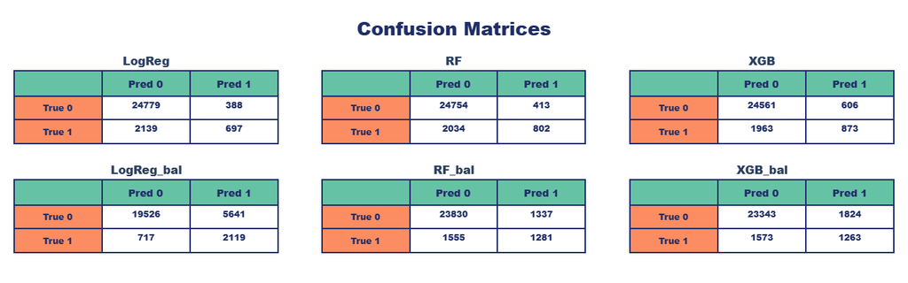

6.2 — plot_6-2.png

```python
models = ["LogReg","RF","XGB","LogReg_bal","RF_bal","XGB_bal"]
cols = {
    "col_header": "#66C2A5",
    "row_header": "#FC8D62",
    "border":     "#1f2e68",
    "text":       "#1f2e68"
}

fig = make_subplots(
    rows=2, cols=3,
    subplot_titles=models,
    specs=[[{"type":"table"}]*3, [{"type":"table"}]*3],
    vertical_spacing=0.1,
    horizontal_spacing=0.05
)

for idx, m in enumerate(models):
    cm = confusion_matrix(y_test, PRED[m])
    tn, fp = cm[0]
    fn, tp = cm[1]
    r, c = divmod(idx, 3)

    fig.add_trace(
        go.Table(
            header=dict(
                values=["", "<b>Pred 0</b>", "<b>Pred 1</b>"],
                fill_color=[cols["col_header"]]*3,
                font=dict(family="Arial Black", size=14, color=cols["border"]),
                align="center",
                height=30,
                line_color=cols["border"], line_width=2
            ),
            cells=dict(
                values=[
                    ["<b>True 0</b>", "<b>True 1</b>"],
                    [tn, fn],
                    [fp, tp]
                ],
                fill_color=[
                    [cols["row_header"], cols["row_header"]],
                    ["white","white"],
                    ["white","white"]
                ],
                font=dict(
                    family="Arial Black",
                    size=12,
                    color=[
                        [cols["border"], cols["border"]],
                        [cols["text"],   cols["text"]],
                        [cols["text"],   cols["text"]]
                    ]
                ),
                align="center",
                height=30,
                line_color=cols["border"], line_width=2
            )
        ),
        row=r+1, col=c+1
    )

fig.update_layout(
    template="plotly_white",
    title_text="Confusion Matrices",
    title_font=dict(family="Arial Black", size=26, color=cols["border"]),
    title_x=0.5,
    height=400, width=1280,
    margin=dict(t=100, l=20, r=20, b=20)
)

for ann in fig.layout.annotations:
    if ann.text in models:
        ann.font.family = "Arial Black"
        ann.font.size = 16

fig.show()
```

### 6.3 - Model comparison: original vs. balanced

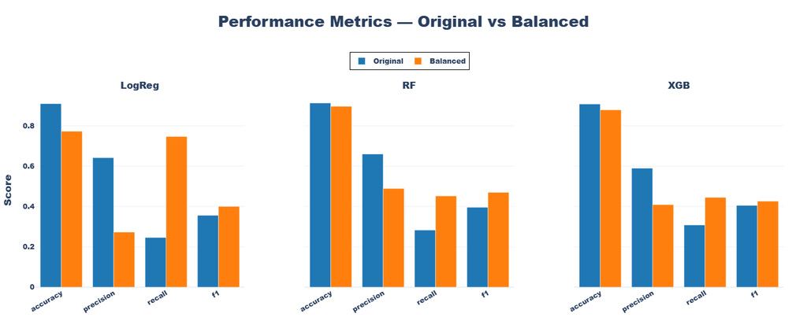

6.3 — plot_6-3.png

```python
pairs = [("LogReg", "LogReg_bal"),
         ("RF",     "RF_bal"),
         ("XGB",    "XGB_bal")]
metrics_to_plot = ["accuracy", "precision", "recall", "f1"]

fig_cmp = make_subplots(
    rows=1, cols=3,
    subplot_titles=[orig for orig, _ in pairs],
    shared_yaxes=True,
    horizontal_spacing=0.08
)

col_unbal = "#1f77b4"
col_bal    = "#ff7f0e"

for i, (unbal, bal) in enumerate(pairs, start=1):
    y_u = metrics.loc[unbal, metrics_to_plot]
    y_b = metrics.loc[bal,  metrics_to_plot]

    fig_cmp.add_trace(
        go.Bar(
            x=metrics_to_plot,
            y=y_u,
            marker_color=col_unbal,
            name="Original",
            showlegend=(i == 1)
        ),
        row=1, col=i
    )

    fig_cmp.add_trace(
        go.Bar(
            x=metrics_to_plot,
            y=y_b,
            marker_color=col_bal,
            name="Balanced",
            showlegend=(i == 1)
        ),
        row=1, col=i
    )

fig_cmp.update_layout(
    template="plotly_white",
    barmode="group",
    title_text="Performance Metrics — Original vs Balanced",
    title_font=dict(size=26, family="Arial Black"),
    title_x=0.5,
    title_y=0.95,
    height=550,
    width=1380,
    yaxis_title="Score",
    margin=dict(t=160, l=40, r=40, b=40),
    font=dict(size=14, family="Arial Black"),
    showlegend=True,
    legend=dict(
        orientation="h",
        yanchor="bottom",
        y=1.12,
        xanchor="center",
        x=0.5,
        bgcolor="rgba(255,255,255,0.8)",
        bordercolor="black",
        borderwidth=1,
        font=dict(size=12, family="Arial Black")
    )
)

for idx in range(1, 4):
    fig_cmp.update_xaxes(
        tickangle=-30,
        tickfont=dict(size=12, family="Arial Black"),
        row=1, col=idx
    )
    fig_cmp.update_yaxes(
        tickfont=dict(size=12, family="Arial Black"),
        row=1, col=idx
    )

for ann in fig_cmp.layout.annotations[:3]:
    ann.font.size = 16
    ann.font.family = "Arial Black"

fig_cmp.show()
```

### 6.4 - Conclusions

In experiments comparing three classifiers trained with and without a re-balanced target, the following was observed:

- **Recall increased significantly** (by 14–50 percentage points).

  > Re-balancing allowed each model to capture many more true positives and miss far fewer cases.
- **Precision and overall accuracy decreased**.

  > The gain in recall outweighed the drop in precision, yielding a stronger balance between sensitivity and specificity.
- **Balanced Random Forest delivered the best compromise** (F1 ≈ 0.47).

  > It achieved higher recall with only a small loss in accuracy, ending up with the top overall F1.
- **Re-balancing is most useful when missing a positive is costlier than a false alarm** (e.g., safety alerts, fraud detection, medical screening).

  > If false positives carry a higher penalty, it may be better to retain the original class distribution.